# R语言与机器学习（上）

## 2.9 数据分箱（等频、等距、基于决策树）

### 什么是数据分箱？

**数据分箱（Binning/Discretization）**：将连续变量转换为离散的区间（箱）。

**用途**： 1. 处理非线性关系 2. 减少噪声影响 3. 提高可解释性

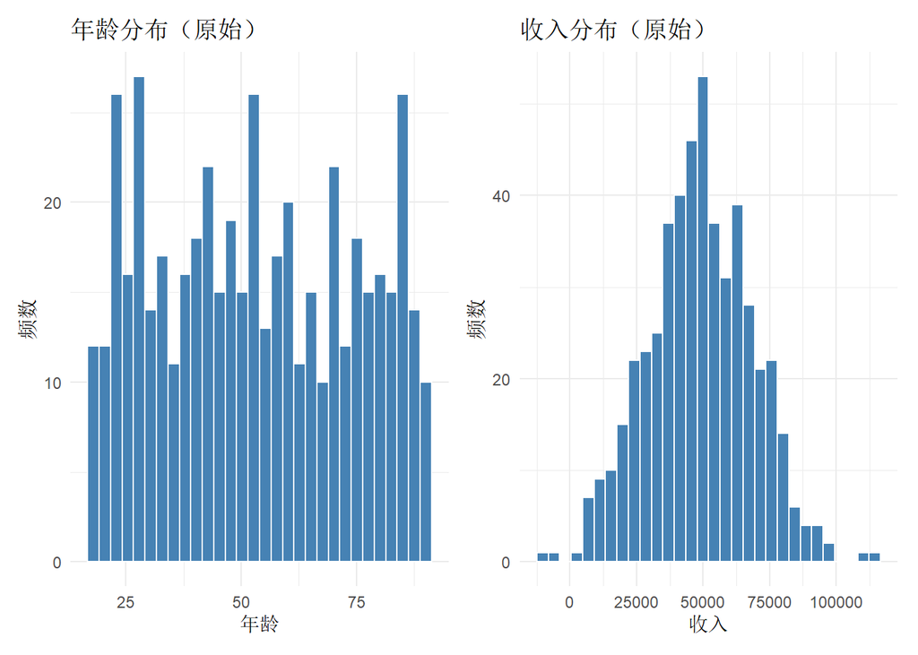

```r
# 创建模拟数据
set.seed(42)
binning_data <- data.frame(
  age = round(runif(500, 18, 90)),
  income = round(rnorm(500, mean = 50000, sd = 20000))
)

# 查看原始数据分布
p1 <- ggplot2::ggplot(binning_data, ggplot2::aes(x = age)) +
  ggplot2::geom_histogram(bins = 30, fill = "steelblue", color = "white") +
  ggplot2::labs(title = "年龄分布（原始）", x = "年龄", y = "频数") +
  ggplot2::theme_minimal()

p2 <- ggplot2::ggplot(binning_data, ggplot2::aes(x = income)) +
  ggplot2::geom_histogram(bins = 30, fill = "steelblue", color = "white") +
  ggplot2::labs(title = "收入分布（原始）", x = "收入", y = "频数") +
  ggplot2::theme_minimal()

p1 + p2
```

### 等距分箱（Equal-width Binning）

**原理**：将数据范围等分为若干区间。

```r
# 等距分箱：将年龄分为5个等宽区间
binning_data$age_equal_width <- cut(
  binning_data$age,
  breaks = 5,
  labels = c("青年", "中青年", "中年", "中老年", "老年")
)

# 查看分箱结果
table(binning_data$age_equal_width)
```

```
##
##   青年 中青年   中年 中老年   老年
##    114     92    110     82    102
```

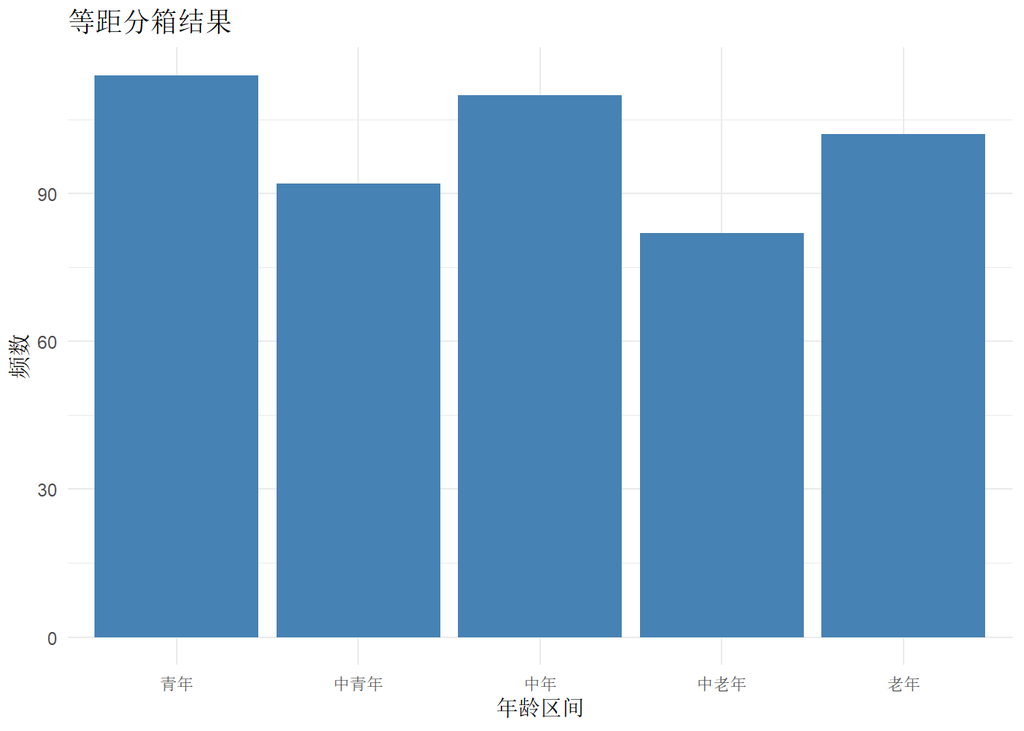

```r
# 可视化
ggplot2::ggplot(binning_data, ggplot2::aes(x = age_equal_width)) +
  ggplot2::geom_bar(fill = "steelblue") +
  ggplot2::labs(
    title = "等距分箱结果",
    x = "年龄区间", y = "频数"
  ) +
  ggplot2::theme_minimal()
```

### 等频分箱（Equal-frequency Binning）

**原理**：每个箱包含大致相同数量的样本。

```r
# 等频分箱：将年龄分为5个等频区间
binning_data$age_equal_freq <- cut(
  binning_data$age,
  breaks = quantile(binning_data$age, probs = seq(0, 1, 0.2)),
  include.lowest = TRUE,
  labels = c("Q1", "Q2", "Q3", "Q4", "Q5")
)

# 查看分箱结果
table(binning_data$age_equal_freq)
```

```
##
##  Q1  Q2  Q3  Q4  Q5
## 102 104  97 101  96
```

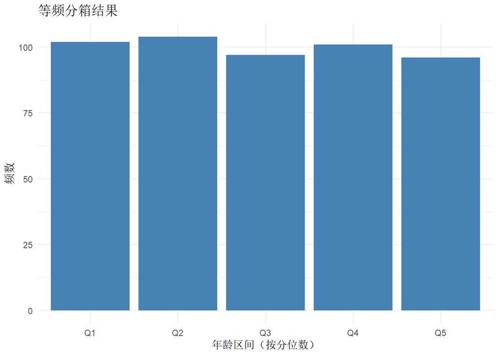

```r
# 可视化
ggplot2::ggplot(binning_data, ggplot2::aes(x = age_equal_freq)) +
  ggplot2::geom_bar(fill = "steelblue") +
  ggplot2::labs(
    title = "等频分箱结果",
    x = "年龄区间（按分位数）", y = "频数"
  ) +
  ggplot2::theme_minimal()
```

### 基于决策树的分箱

**原理**：使用决策树找到最优分割点，使目标变量的区分度最大。

```r
# 创建带目标变量的数据
set.seed(42)
binning_data$risk <- ifelse(
  binning_data$age < 40,
  sample(c(0, 1), sum(binning_data$age < 40), replace = TRUE, prob = c(0.8, 0.2)),
  ifelse(
    binning_data$age < 60,
    sample(c(0, 1), sum(binning_data$age >= 40 & binning_data$age < 60), replace = TRUE, prob = c(0.5, 0.5)),
    sample(c(0, 1), sum(binning_data$age >= 60), replace = TRUE, prob = c(0.3, 0.7))
  )
)

# 使用决策树找到最优分割点
tree_model <- rpart::rpart(
  risk ~ age,
  data = binning_data,
  method = "class",
  control = rpart::rpart.control(maxdepth = 3, minbucket = 30)
)

# 查看决策树
print(tree_model)
```

```
## n= 500
##
## node), split, n, loss, yval, (yprob)
##       * denotes terminal node
##
## 1) root 500 242 1 (0.4840000 0.5160000)
##   2) age< 39.5 151  25 0 (0.8344371 0.1655629) *
##   3) age>=39.5 349 116 1 (0.3323782 0.6676218) *
```

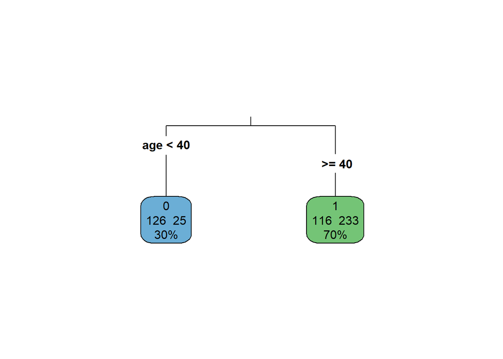

```r
# 可视化决策树
rpart.plot::rpart.plot(tree_model, type = 3, extra = 101)
```

```r
# 根据决策树结果进行分箱
binning_data$age_tree_bin <- cut(
  binning_data$age,
  breaks = c(-Inf, 39.5, 59.5, Inf),
  labels = c("低风险", "中风险", "高风险")
)

# 查看分箱后的风险分布
risk_by_bin <- binning_data %>%
  dplyr::group_by(age_tree_bin) %>%
  dplyr::summarise(
    n = n(),
    risk_rate = mean(risk),
    .groups = "drop"
  )

print(risk_by_bin)
```

```
## # A tibble: 3 × 3
##   age_tree_bin     n risk_rate
##   <fct>        <int>     <dbl>
## 1 低风险         151     0.166
## 2 中风险         152     0.612
## 3 高风险         197     0.711
```

### 分箱方法对比

| 方法 | 优点 | 缺点 | 适用场景 |
| --- | --- | --- | --- |
| 等距分箱 | 简单直观 | 对异常值敏感 | 均匀分布数据 |
| 等频分箱 | 每箱样本均衡 | 边界可能不直观 | 偏态分布数据 |
| 决策树分箱 | 考虑目标变量 | 需要有标签 | 有监督学习 |

### 意义与使用场景

**核心意义**：数据分箱可以将复杂的非线性关系简化为分段线性关系，提高模型的可解释性。

**举例**：年龄与疾病风险的关系

**场景**：分析年龄与心血管疾病风险的关系。

**为什么需要分箱？**

年龄与风险的关系可能是非线性的：青年风险低，中年风险逐渐上升，老年风险高但可能趋于平稳。分箱后可以更好地捕捉这种非线性关系，同时结果更易于解释（如”60岁以上为高风险人群”）。

**如何选择分箱方法？**

如果目的是探索性分析，用等距分箱便于可视化。如果目的是建模，用决策树分箱可以找到最优分割点。如果数据偏态严重，用等频分箱更稳健。

# 第三章 模型评估与验证

## 3.1 分类评估指标：准确率、精确率、召回率、F1分数

### 混淆矩阵基础

分类模型的预测结果可以用**混淆矩阵（Confusion Matrix）**来表示：

|  | 预测为正 | 预测为负 |
| --- | --- | --- |
| 实际为正 | TP（真正例） | FN（假负例） |
| 实际为负 | FP（假正例） | TN（真负例） |

### 四大核心指标

**准确率（Accuracy）**：

$$Accuracy = \frac{TP + TN}{TP + TN + FP +
FN}$$

**精确率（Precision）**：

$$Precision = \frac{TP}{TP +
FP}$$

**召回率（Recall/Sensitivity）**：

$$Recall = \frac{TP}{TP + FN}$$

**F1分数**：

$$F1 = 2 \times \frac{Precision \times
Recall}{Precision + Recall}$$

```r
# 创建模拟预测结果
set.seed(42)
n <- 200

# 模拟真实标签和预测概率
actual <- sample(c(0, 1), n, replace = TRUE, prob = c(0.7, 0.3))
pred_prob <- runif(n)
predicted <- ifelse(pred_prob > 0.5, 1, 0)

# 计算混淆矩阵
conf_matrix <- table(实际 = actual, 预测 = predicted)
print(conf_matrix)
```

```
##     预测
## 实际  0  1
##    0 77 52
##    1 39 32
```

```r
# 提取混淆矩阵元素
TN <- conf_matrix[1, 1]
FP <- conf_matrix[1, 2]
FN <- conf_matrix[2, 1]
TP <- conf_matrix[2, 2]

# 计算各指标
accuracy <- (TP + TN) / sum(conf_matrix)
precision <- TP / (TP + FP)
recall <- TP / (TP + FN)
f1 <- 2 * precision * recall / (precision + recall)

# 结果汇总
metrics_df <- data.frame(
  指标 = c("准确率", "精确率", "召回率", "F1分数"),
  公式 = c("(TP+TN)/Total", "TP/(TP+FP)", "TP/(TP+FN)", "2*P*R/(P+R)"),
  值 = c(accuracy, precision, recall, f1)
)

print(metrics_df)
```

```
##     指标          公式        值
## 1 准确率 (TP+TN)/Total 0.5450000
## 2 精确率    TP/(TP+FP) 0.3809524
## 3 召回率    TP/(TP+FN) 0.4507042
## 4 F1分数   2*P*R/(P+R) 0.4129032
```

### 使用caret计算混淆矩阵

```r
# 使用caret包计算完整的混淆矩阵
confusion_result <- caret::confusionMatrix(
  factor(predicted, levels = c(0, 1)),
  factor(actual, levels = c(0, 1)),
  positive = "1"
)

print(confusion_result)
```

```
## Confusion Matrix and Statistics
##
##           Reference
## Prediction  0  1
##          0 77 39
##          1 52 32
##
##                Accuracy : 0.545
##                  95% CI : (0.4733, 0.6154)
##     No Information Rate : 0.645
##     P-Value [Acc > NIR] : 0.9986
##
##                   Kappa : 0.0457
##
##  Mcnemar's Test P-Value : 0.2084
##
##             Sensitivity : 0.4507
##             Specificity : 0.5969
##          Pos Pred Value : 0.3810
##          Neg Pred Value : 0.6638
##              Prevalence : 0.3550
##          Detection Rate : 0.1600
##    Detection Prevalence : 0.4200
##       Balanced Accuracy : 0.5238
##
##        'Positive' Class : 1
##
```

### 指标选择指南

| 场景 | 优先指标 | 原因 |
| --- | --- | --- |
| 类别平衡 | 准确率 | 整体性能 |
| 疾病筛查 | 召回率 | 不漏诊 |
| 确诊检查 | 精确率 | 不误诊 |
| 综合评估 | F1分数 | 平衡P和R |

### 意义与使用场景

**核心意义**：不同指标反映模型不同侧面的性能，需根据实际需求选择。

**举例**：癌症筛查模型

**场景**：开发一个乳腺癌筛查模型，用于大规模人群筛查。

**为什么召回率更重要？**

在筛查场景中，漏诊（假阴性）的代价远高于误诊（假阳性）。漏诊可能导致患者错过最佳治疗时机，而误诊只是需要进一步检查确认。因此，应该优先优化召回率，确保尽可能多地识别出真正的患者。

## 3.2 混淆矩阵（confusion matrix）

### 混淆矩阵的完整结构

对于二分类问题，混淆矩阵包含四个基本元素：

[figure not shown]

```r
# 可视化混淆矩阵
conf_df <- data.frame(
  预测 = rep(c("预测为正", "预测为负"), each = 2),
  实际 = rep(c("实际为正", "实际为负"), 2),
  数值 = c(TP, FN, FP, TN)
)

conf_df$预测 <- factor(conf_df$预测, levels = c("预测为正", "预测为负"))
conf_df$实际 <- factor(conf_df$实际, levels = c("实际为正", "实际为负"))

ggplot2::ggplot(conf_df, ggplot2::aes(x = 预测, y = 实际, fill = 数值)) +
  ggplot2::geom_tile(color = "white", linewidth = 1) +
  ggplot2::geom_text(ggplot2::aes(label = 数值), size = 6) +
  ggplot2::scale_fill_gradient(low = "lightblue", high = "steelblue") +
  ggplot2::labs(
    title = "混淆矩阵可视化",
    x = "预测值", y = "实际值"
  ) +
  ggplot2::theme_minimal() +
  ggplot2::theme(legend.position = "none")
```

### 多分类混淆矩阵

```r
# 多分类混淆矩阵示例
set.seed(42)
multi_actual <- sample(c("A", "B", "C"), 200, replace = TRUE)
multi_pred <- sample(c("A", "B", "C"), 200, replace = TRUE,
                     prob = c(0.4, 0.35, 0.25))

# 计算多分类混淆矩阵
multi_conf <- table(实际 = multi_actual, 预测 = multi_pred)
print(multi_conf)
```

```
##     预测
## 实际  A  B  C
##    A 28 31 16
##    B 37 22 19
##    C 24 11 12
```

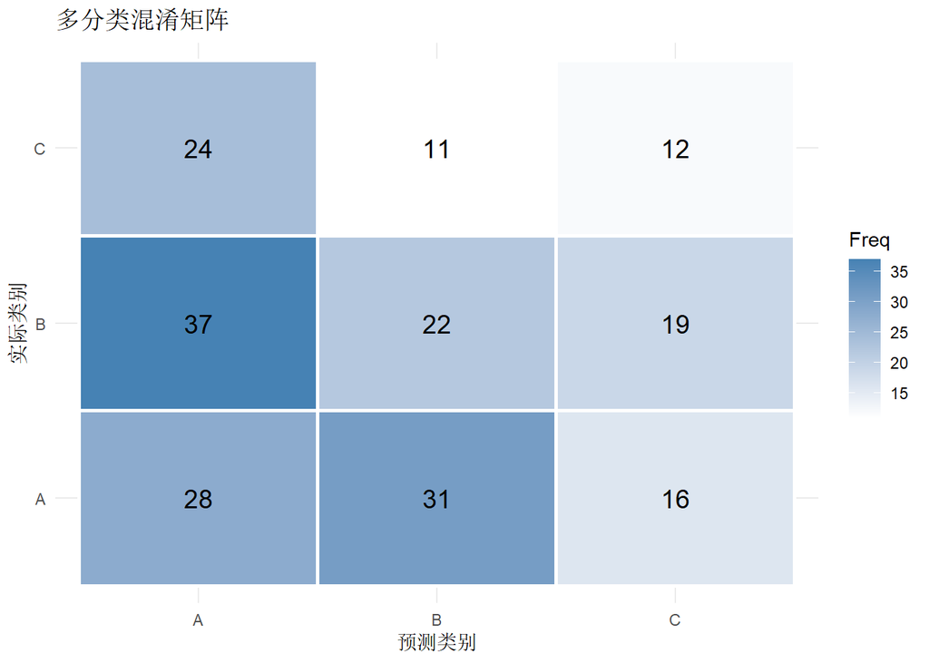

```r
# 可视化
multi_conf_df <- as.data.frame(multi_conf)

ggplot2::ggplot(multi_conf_df, ggplot2::aes(x = 预测, y = 实际, fill = Freq)) +
  ggplot2::geom_tile(color = "white", linewidth = 1) +
  ggplot2::geom_text(ggplot2::aes(label = Freq), size = 5) +
  ggplot2::scale_fill_gradient(low = "white", high = "steelblue") +
  ggplot2::labs(
    title = "多分类混淆矩阵",
    x = "预测类别", y = "实际类别"
  ) +
  ggplot2::theme_minimal()
```

### 从混淆矩阵衍生更多指标

```r
# 更多衍生指标
specificity <- TN / (TN + FP)  # 特异度
npv <- TN / (TN + FN)          # 阴性预测值
fpr <- FP / (TN + FP)          # 假正率
fnr <- FN / (TP + FN)          # 假负率

derived_metrics <- data.frame(
  指标 = c("特异度（Specificity）", "阴性预测值（NPV）",
           "假正率（FPR）", "假负率（FNR）"),
  公式 = c("TN/(TN+FP)", "TN/(TN+FN)", "FP/(TN+FP)", "FN/(TP+FN)"),
  值 = c(specificity, npv, fpr, fnr)
)

print(derived_metrics)
```

```
##                    指标       公式        值
## 1 特异度（Specificity） TN/(TN+FP) 0.5968992
## 2     阴性预测值（NPV） TN/(TN+FN) 0.6637931
## 3         假正率（FPR） FP/(TN+FP) 0.4031008
## 4         假负率（FNR） FN/(TP+FN) 0.5492958
```

## 3.3 ROC曲线与AUC

### ROC曲线原理

**ROC曲线（Receiver Operating Characteristic Curve）**：展示不同阈值下真阳性率（TPR）和假阳性率（FPR）的关系。

- **横轴**：假阳性率 FPR = FP / (FP + TN)
- **纵轴**：真阳性率 TPR = TP / (TP + FN) = 召回率

**AUC（Area Under Curve）**：ROC曲线下的面积，衡量模型整体分类能力。

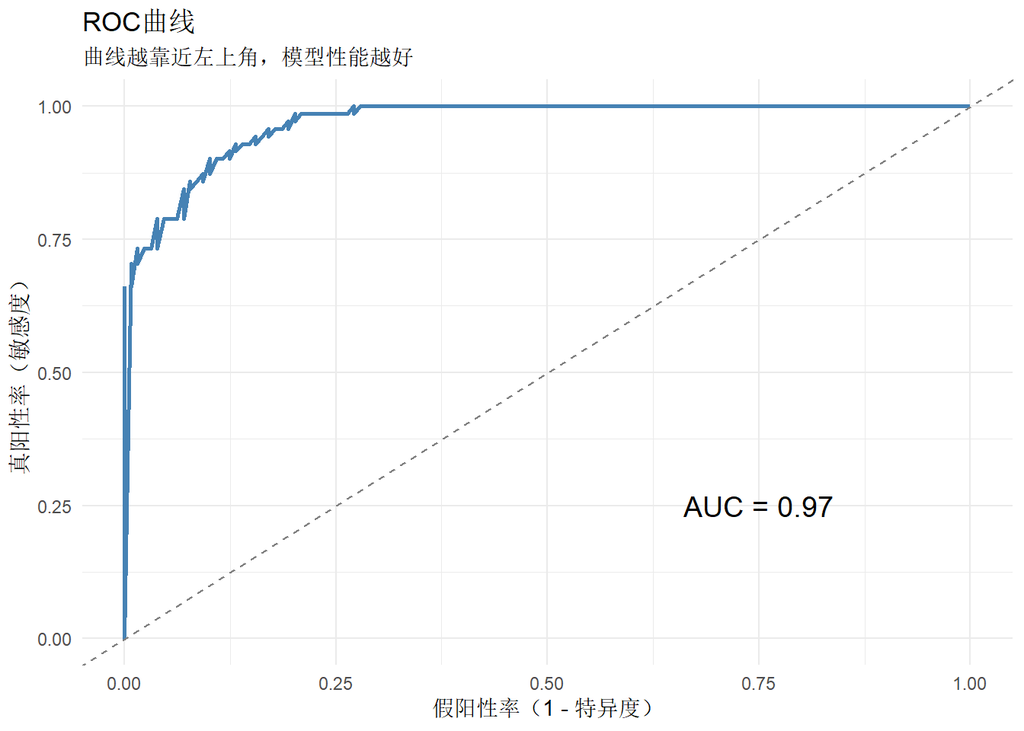

```r
# 使用pROC包绘制ROC曲线
set.seed(42)
n <- 200

# 模拟数据
actual <- sample(c(0, 1), n, replace = TRUE, prob = c(0.7, 0.3))
# 好的模型：预测概率与真实标签相关
pred_prob <- ifelse(actual == 1,
                    rbeta(n, 5, 2),   # 正类：概率偏高
                    rbeta(n, 2, 5))   # 负类：概率偏低

# 计算ROC曲线
roc_obj <- pROC::roc(actual, pred_prob, quiet = TRUE)

# 绘制ROC曲线
ggplot2::ggplot(data.frame(
  specificity = roc_obj$specificities,
  sensitivity = roc_obj$sensitivities
), ggplot2::aes(x = 1 - specificity, y = sensitivity)) +
  ggplot2::geom_line(color = "steelblue", linewidth = 1) +
  ggplot2::geom_abline(intercept = 0, slope = 1, linetype = "dashed", color = "gray50") +
  ggplot2::annotate("text", x = 0.75, y = 0.25,
                    label = paste("AUC =", round(pROC::auc(roc_obj), 3)),
                    size = 5) +
  ggplot2::labs(
    title = "ROC曲线",
    subtitle = "曲线越靠近左上角，模型性能越好",
    x = "假阳性率（1 - 特异度）", y = "真阳性率（敏感度）"
  ) +
  ggplot2::theme_minimal()
```

### AUC的含义

| AUC值 | 模型性能 |
| --- | --- |
| 0.5 | 随机猜测 |
| 0.5-0.7 | 较差 |
| 0.7-0.8 | 一般 |
| 0.8-0.9 | 良好 |
| 0.9-1.0 | 优秀 |

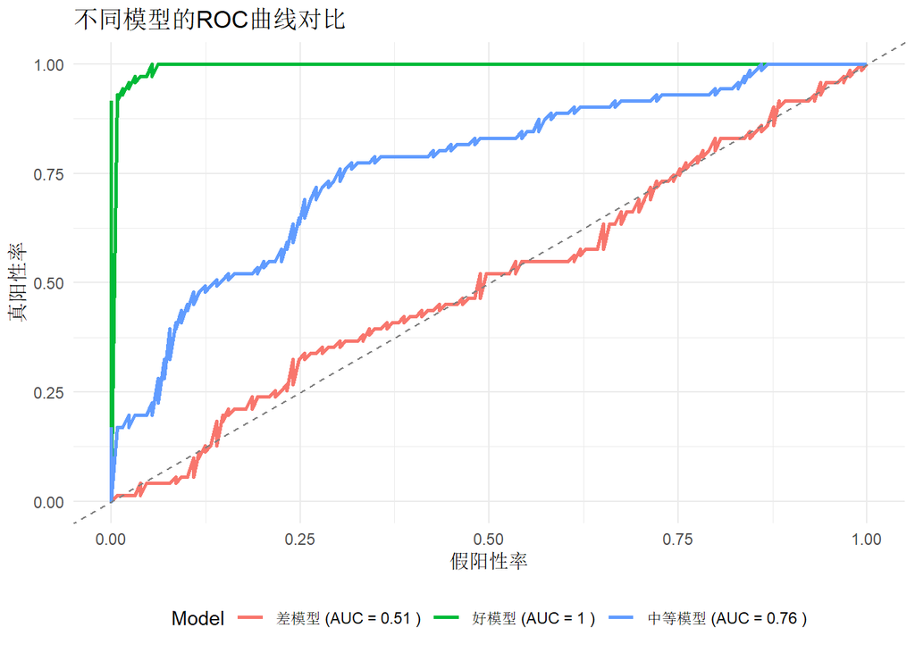

```r
# 比较不同模型的ROC曲线
set.seed(42)

# 模拟三个不同质量的模型
# 好模型
pred_good <- ifelse(actual == 1, rbeta(n, 6, 1.5), rbeta(n, 1.5, 6))
# 中等模型
pred_medium <- ifelse(actual == 1, rbeta(n, 3, 2), rbeta(n, 2, 3))
# 差模型
pred_poor <- ifelse(actual == 1, rbeta(n, 2, 2), rbeta(n, 2, 2))

# 计算ROC
roc_good <- pROC::roc(actual, pred_good, quiet = TRUE)
roc_medium <- pROC::roc(actual, pred_medium, quiet = TRUE)
roc_poor <- pROC::roc(actual, pred_poor, quiet = TRUE)

# 创建数据框
roc_compare <- rbind(
  data.frame(FPR = 1 - roc_good$specificities, TPR = roc_good$sensitivities,
             Model = paste("好模型 (AUC =", round(pROC::auc(roc_good), 2), ")")),
  data.frame(FPR = 1 - roc_medium$specificities, TPR = roc_medium$sensitivities,
             Model = paste("中等模型 (AUC =", round(pROC::auc(roc_medium), 2), ")")),
  data.frame(FPR = 1 - roc_poor$specificities, TPR = roc_poor$sensitivities,
             Model = paste("差模型 (AUC =", round(pROC::auc(roc_poor), 2), ")"))
)

ggplot2::ggplot(roc_compare, ggplot2::aes(x = FPR, y = TPR, color = Model)) +
  ggplot2::geom_line(linewidth = 1) +
  ggplot2::geom_abline(intercept = 0, slope = 1, linetype = "dashed", color = "gray50") +
  ggplot2::labs(
    title = "不同模型的ROC曲线对比",
    x = "假阳性率", y = "真阳性率"
  ) +
  ggplot2::theme_minimal() +
  ggplot2::theme(legend.position = "bottom")
```

### 意义与使用场景

**核心意义**：ROC曲线和AUC提供了模型在不同阈值下的整体性能评估，不依赖于特定阈值。

**举例**：疾病诊断模型评估

**场景**：评估一个糖尿病风险预测模型。

**为什么用AUC而不是准确率？**

准确率依赖于阈值选择。如果阈值设为0.5，准确率可能是80%；如果阈值设为0.3，准确率可能变为75%。AUC综合了所有可能阈值下的性能，更全面地评估模型质量。

## 3.4 PR曲线与平均精度（AP）

### PR曲线原理

**PR曲线（Precision-Recall Curve）**：展示不同阈值下精确率和召回率的关系。

- **横轴**：召回率（Recall）
- **纵轴**：精确率（Precision）

**适用场景**：类别不平衡时，PR曲线比ROC曲线更能反映模型性能。

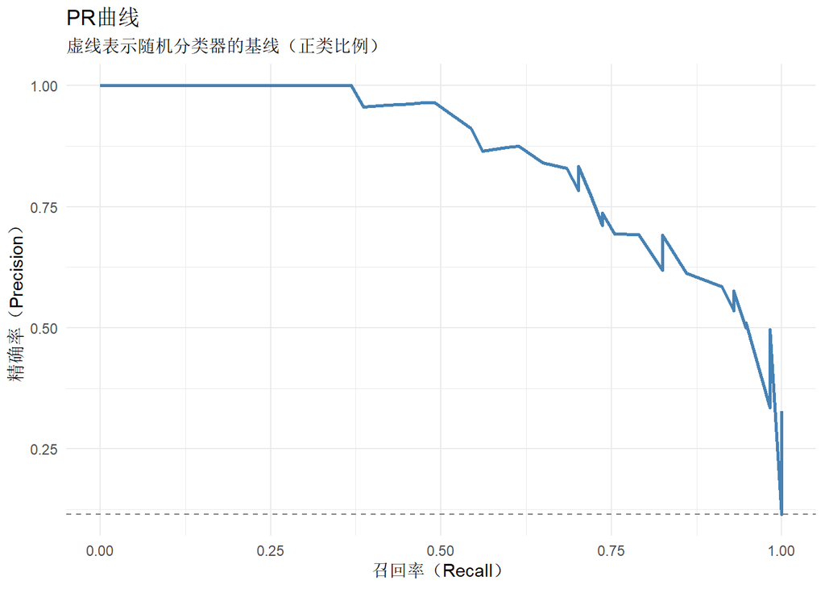

```r
# 绘制PR曲线
set.seed(42)

# 创建不平衡数据
actual_imb <- sample(c(0, 1), 500, replace = TRUE, prob = c(0.9, 0.1))
pred_imb <- ifelse(actual_imb == 1, rbeta(500, 5, 2), rbeta(500, 2, 5))

# 计算不同阈值下的精确率和召回率
thresholds <- seq(0, 1, by = 0.01)
pr_data <- data.frame()

for (thresh in thresholds) {
  pred_class <- ifelse(pred_imb >= thresh, 1, 0)

  TP <- sum(pred_class == 1 & actual_imb == 1)
  FP <- sum(pred_class == 1 & actual_imb == 0)
  FN <- sum(pred_class == 0 & actual_imb == 1)

  precision <- ifelse(TP + FP == 0, 1, TP / (TP + FP))
  recall <- ifelse(TP + FN == 0, 0, TP / (TP + FN))

  pr_data <- rbind(pr_data, data.frame(
    threshold = thresh,
    precision = precision,
    recall = recall
  ))
}

# 绘制PR曲线
ggplot2::ggplot(pr_data, ggplot2::aes(x = recall, y = precision)) +
  ggplot2::geom_line(color = "steelblue", linewidth = 1) +
  ggplot2::geom_hline(yintercept = mean(actual_imb), linetype = "dashed",
                       color = "gray50") +
  ggplot2::labs(
    title = "PR曲线",
    subtitle = "虚线表示随机分类器的基线（正类比例）",
    x = "召回率（Recall）", y = "精确率（Precision）"
  ) +
  ggplot2::theme_minimal()
```

### ROC vs PR曲线对比

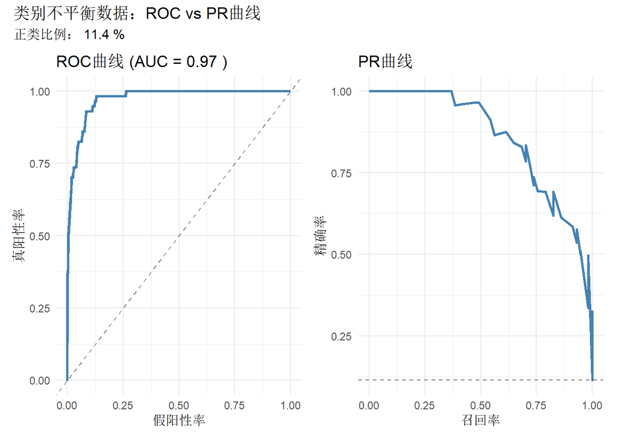

```r
# 对比ROC和PR曲线在不平衡数据上的表现
# 计算ROC
roc_imb <- pROC::roc(actual_imb, pred_imb, quiet = TRUE)

# 创建对比图
p1 <- ggplot2::ggplot(data.frame(
  FPR = 1 - roc_imb$specificities,
  TPR = roc_imb$sensitivities
), ggplot2::aes(x = FPR, y = TPR)) +
  ggplot2::geom_line(color = "steelblue", linewidth = 1) +
  ggplot2::geom_abline(intercept = 0, slope = 1, linetype = "dashed", color = "gray50") +
  ggplot2::labs(
    title = paste("ROC曲线 (AUC =", round(pROC::auc(roc_imb), 2), ")"),
    x = "假阳性率", y = "真阳性率"
  ) +
  ggplot2::theme_minimal()

p2 <- ggplot2::ggplot(pr_data, ggplot2::aes(x = recall, y = precision)) +
  ggplot2::geom_line(color = "steelblue", linewidth = 1) +
  ggplot2::geom_hline(yintercept = mean(actual_imb), linetype = "dashed", color = "gray50") +
  ggplot2::labs(
    title = "PR曲线",
    x = "召回率", y = "精确率"
  ) +
  ggplot2::theme_minimal()

p1 + p2 + patchwork::plot_annotation(
  title = "类别不平衡数据：ROC vs PR曲线",
  subtitle = paste("正类比例：", mean(actual_imb) * 100, "%")
)
```

### 意义与使用场景

**核心意义**：PR曲线在类别不平衡时更能反映模型对少数类的识别能力。

**举例**：罕见疾病诊断

**场景**：诊断一种发病率为1%的罕见疾病。

**为什么用PR曲线？**

在极度不平衡的数据中，ROC曲线可能过于乐观。一个”全预测为健康”的模型，ROC曲线看起来还不错（因为TN很高），但PR曲线会清楚地显示模型对患者的识别能力很差。

## 3.5 回归评估指标

### 常用回归指标

| 指标 | 公式 | 特点 |
| --- | --- | --- |
| MAE | $\frac{1}{n}\sum\|y_i - \hat{y}_i\|$ | 对异常值稳健 |
| MSE | $\frac{1}{n}\sum(y_i - \hat{y}_i)^2$ | 对大误差敏感 |
| RMSE | $\sqrt{MSE}$ | 与原数据同量纲 |
| R² | $1 - \frac{SS_{res}}{SS_{tot}}$ | 解释方差比例 |

```r
# 回归评估指标示例
set.seed(42)
n <- 100

# 模拟数据
x <- runif(n, 0, 10)
y_true <- 2 * x + 3
y_pred <- y_true + rnorm(n, 0, 2)  # 添加预测误差

# 计算各指标
residuals <- y_true - y_pred

MAE <- mean(abs(residuals))
MSE <- mean(residuals^2)
RMSE <- sqrt(MSE)
SS_res <- sum(residuals^2)
SS_tot <- sum((y_true - mean(y_true))^2)
R2 <- 1 - SS_res / SS_tot

# 调整R²（假设有1个自变量）
n <- length(y_true)
p <- 1
R2_adj <- 1 - (1 - R2) * (n - 1) / (n - p - 1)

reg_metrics <- data.frame(
  指标 = c("MAE", "MSE", "RMSE", "R²", "调整R²"),
  值 = c(MAE, MSE, RMSE, R2, R2_adj)
)

print(reg_metrics)
```

```
##     指标        值
## 1    MAE 1.4575998
## 2    MSE 3.4293694
## 3   RMSE 1.8518557
## 4     R² 0.9050144
## 5 调整R² 0.9040451
```

### 可视化预测效果

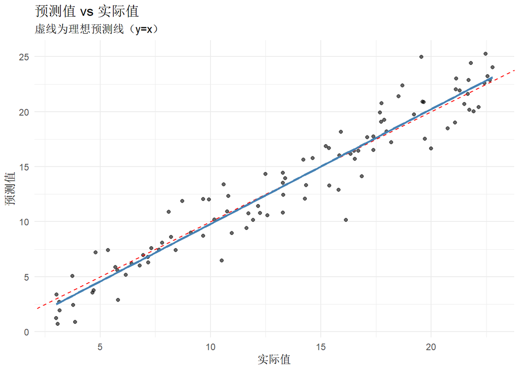

```r
# 预测值 vs 实际值
plot_data <- data.frame(
  实际值 = y_true,
  预测值 = y_pred
)

ggplot2::ggplot(plot_data, ggplot2::aes(x = 实际值, y = 预测值)) +
  ggplot2::geom_point(alpha = 0.6) +
  ggplot2::geom_abline(intercept = 0, slope = 1, color = "red", linetype = "dashed") +
  ggplot2::geom_smooth(method = "lm", se = FALSE, color = "steelblue") +
  ggplot2::labs(
    title = "预测值 vs 实际值",
    subtitle = "虚线为理想预测线（y=x）",
    x = "实际值", y = "预测值"
  ) +
  ggplot2::theme_minimal()
```

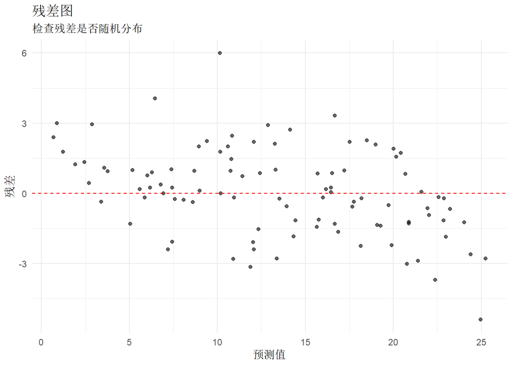

```r
# 残差图
resid_data <- data.frame(
  预测值 = y_pred,
  残差 = residuals
)

ggplot2::ggplot(resid_data, ggplot2::aes(x = 预测值, y = 残差)) +
  ggplot2::geom_point(alpha = 0.6) +
  ggplot2::geom_hline(yintercept = 0, color = "red", linetype = "dashed") +
  ggplot2::labs(
    title = "残差图",
    subtitle = "检查残差是否随机分布",
    x = "预测值", y = "残差"
  ) +
  ggplot2::theme_minimal()
```

### 意义与使用场景

**核心意义**：回归指标衡量预测值与实际值的偏差程度，R²反映模型解释力。

**举例**：医疗费用预测

**场景**：预测患者的年度医疗费用。

**如何解读指标？**

MAE = 2000元：平均预测误差为2000元。RMSE = 3000元：考虑到大误差的影响，误差的”典型值”为3000元。R² = 0.75：模型解释了75%的费用变异。

## 3.6 多分类评估

### 宏平均、微平均、加权平均

对于多分类问题，需要将各类别的指标进行汇总：

| 方法 | 计算方式 | 特点 |
| --- | --- | --- |
| 宏平均 | 各类别指标的算术平均 | 平等对待每个类别 |
| 微平均 | 汇总所有TP/FP/FN后计算 | 受多数类影响大 |
| 加权平均 | 按类别样本数加权平均 | 考虑类别不平衡 |

```r
# 多分类评估示例
set.seed(42)

# 模拟三分类数据
n <- 300
multi_actual <- sample(c("A", "B", "C"), n, replace = TRUE, prob = c(0.5, 0.3, 0.2))

# 模拟预测（有一定准确率）
multi_pred <- sapply(multi_actual, function(x) {
  if (x == "A") sample(c("A", "B", "C"), 1, prob = c(0.7, 0.2, 0.1))
  else if (x == "B") sample(c("A", "B", "C"), 1, prob = c(0.2, 0.6, 0.2))
  else sample(c("A", "B", "C"), 1, prob = c(0.1, 0.2, 0.7))
})

# 混淆矩阵
multi_conf <- table(实际 = multi_actual, 预测 = multi_pred)
print(multi_conf)
```

```
##     预测
## 实际   A   B   C
##    A 112  21  18
##    B  24  60   7
##    C   4  10  44
```

```r
# 计算每个类别的指标
calc_class_metrics <- function(conf_matrix, class_name) {
  TP <- conf_matrix[class_name, class_name]
  FP <- sum(conf_matrix[, class_name]) - TP
  FN <- sum(conf_matrix[class_name, ]) - TP

  precision <- TP / (TP + FP)
  recall <- TP / (TP + FN)
  f1 <- 2 * precision * recall / (precision + recall)

  return(c(Precision = precision, Recall = recall, F1 = f1))
}

class_metrics <- data.frame()
for (cls in c("A", "B", "C")) {
  metrics <- calc_class_metrics(multi_conf, cls)
  class_metrics <- rbind(class_metrics, data.frame(
    类别 = cls,
    Precision = metrics["Precision"],
    Recall = metrics["Recall"],
    F1 = metrics["F1"]
  ))
}

# 计算宏平均
macro_avg <- data.frame(
  类别 = "宏平均",
  Precision = mean(class_metrics$Precision),
  Recall = mean(class_metrics$Recall),
  F1 = mean(class_metrics$F1)
)

# 计算加权平均
class_counts <- table(multi_actual)
weights <- class_counts / sum(class_counts)
weighted_avg <- data.frame(
  类别 = "加权平均",
  Precision = sum(class_metrics$Precision * weights),
  Recall = sum(class_metrics$Recall * weights),
  F1 = sum(class_metrics$F1 * weights)
)

# 汇总结果
all_metrics <- rbind(class_metrics, macro_avg, weighted_avg)

print(all_metrics)
```

```
##                类别 Precision    Recall        F1
## Precision         A 0.8000000 0.7417219 0.7697595
## Precision1        B 0.6593407 0.6593407 0.6593407
## Precision2        C 0.6376812 0.7586207 0.6929134
## 1            宏平均 0.6990073 0.7198944 0.7073378
## 11         加权平均 0.7259517 0.7200000 0.7214088
```

### 使用caret计算多分类指标

```r
# 使用caret计算多分类混淆矩阵
multi_confusion <- caret::confusionMatrix(
  factor(multi_pred, levels = c("A", "B", "C")),
  factor(multi_actual, levels = c("A", "B", "C"))
)

print(multi_confusion$byClass)
```

```
##          Sensitivity Specificity Pos Pred Value Neg Pred Value Precision
## Class: A   0.7417219   0.8120805      0.8000000      0.7562500 0.8000000
## Class: B   0.6593407   0.8516746      0.6593407      0.8516746 0.6593407
## Class: C   0.7586207   0.8966942      0.6376812      0.9393939 0.6376812
##             Recall        F1 Prevalence Detection Rate Detection Prevalence
## Class: A 0.7417219 0.7697595  0.5033333      0.3733333            0.4666667
## Class: B 0.6593407 0.6593407  0.3033333      0.2000000            0.3033333
## Class: C 0.7586207 0.6929134  0.1933333      0.1466667            0.2300000
##          Balanced Accuracy
## Class: A         0.7769012
## Class: B         0.7555077
## Class: C         0.8276575
```

## 3.7 交叉验证的变体

### 时间序列交叉验证

对于时间序列数据，不能随机划分，必须按时间顺序。

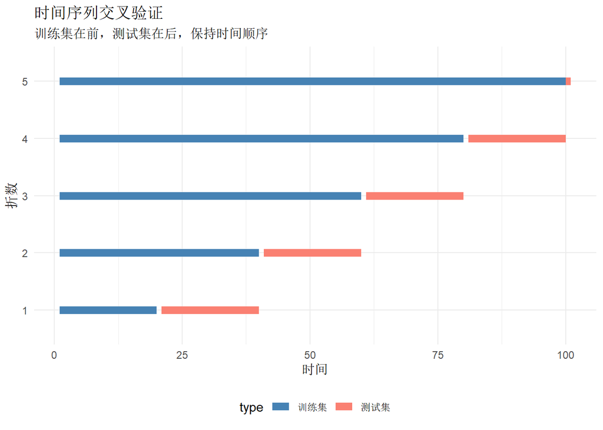

```r
# 时间序列交叉验证示意
n <- 100
time_series <- 1:n

# 创建时间序列CV的划分
ts_splits <- data.frame()

for (i in 1:5) {
  train_end <- 20 * i
  test_start <- train_end + 1
  test_end <- min(train_end + 20, n)

  ts_splits <- rbind(ts_splits, data.frame(
    fold = i,
    type = "训练集",
    start = 1,
    end = train_end
  ))
  ts_splits <- rbind(ts_splits, data.frame(
    fold = i,
    type = "测试集",
    start = test_start,
    end = test_end
  ))
}

# 可视化
ts_splits$fold <- factor(ts_splits$fold)
ts_splits$type <- factor(ts_splits$type, levels = c("训练集", "测试集"))

ggplot2::ggplot(ts_splits, ggplot2::aes(x = start, xend = end, y = fold, yend = fold, color = type)) +
  ggplot2::geom_segment(linewidth = 3) +
  ggplot2::scale_color_manual(values = c("训练集" = "steelblue", "测试集" = "salmon")) +
  ggplot2::labs(
    title = "时间序列交叉验证",
    subtitle = "训练集在前，测试集在后，保持时间顺序",
    x = "时间", y = "折数"
  ) +
  ggplot2::theme_minimal() +
  ggplot2::theme(legend.position = "bottom")
```

### 分组交叉验证

当数据有分组结构时（如同一患者的多次测量），需要确保同一组的数据不会同时出现在训练集和测试集。

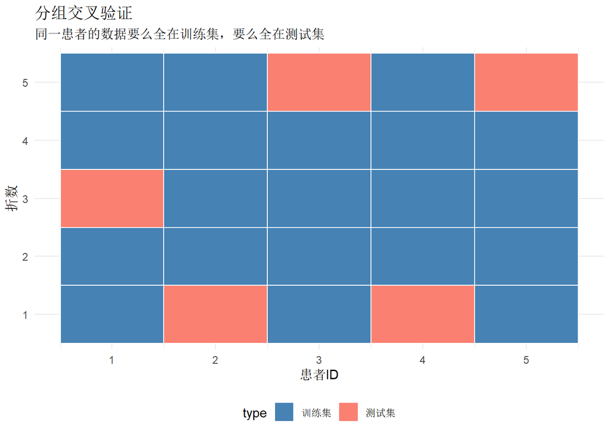

```r
# 分组交叉验证示意
set.seed(42)

# 创建分组数据（5个患者，每个患者10次测量）
group_data <- data.frame(
  patient_id = rep(1:5, each = 10),
  measurement = 1:50
)

# 使用caret创建分组划分
group_folds <- caret::createFolds(group_data$patient_id, k = 5)

# 可视化分组CV
group_viz <- data.frame()
for (i in 1:5) {
  test_patients <- unique(group_data$patient_id)[group_folds[[i]]]
  test_idx <- group_data$patient_id %in% test_patients

  group_viz <- rbind(group_viz, data.frame(
    fold = i,
    patient = group_data$patient_id,
    type = ifelse(test_idx, "测试集", "训练集")
  ))
}

group_viz$fold <- factor(group_viz$fold)
group_viz$type <- factor(group_viz$type, levels = c("训练集", "测试集"))

ggplot2::ggplot(group_viz, ggplot2::aes(x = patient, y = fold, fill = type)) +
  ggplot2::geom_tile(color = "white", linewidth = 0.5) +
  ggplot2::scale_fill_manual(values = c("训练集" = "steelblue", "测试集" = "salmon")) +
  ggplot2::labs(
    title = "分组交叉验证",
    subtitle = "同一患者的数据要么全在训练集，要么全在测试集",
    x = "患者ID", y = "折数"
  ) +
  ggplot2::theme_minimal() +
  ggplot2::theme(legend.position = "bottom")
```

### 意义与使用场景

**核心意义**：交叉验证变体针对特殊数据结构设计，确保评估结果可靠，避免数据泄露。

**举例**：预测患者再入院风险

**为什么需要选择正确的交叉验证方法？**

患者数据有特殊结构：同一患者可能有多次住院记录，时间序列数据有先后顺序。如果用普通K折交叉验证，同一患者的数据可能同时出现在训练集和测试集，导致过于乐观的评估结果；或者用未来的数据预测过去，不符合实际应用场景。

**研究目的是什么？**

1. 时间序列CV：按时间顺序划分，用历史数据预测未来
2. 分组CV：确保同一患者数据不跨集，评估模型对新患者的泛化能力
3. 分层CV：保持各类别比例，适用于不平衡数据

**可能得到什么样的结果？**

使用正确的交叉验证方法后，模型评估结果可能比普通CV低5-10%，但这才是真实的泛化性能。例如，普通CV显示AUC=0.85，分组CV显示AUC=0.78，后者更接近实际部署效果。

**需要注意什么？**

选择交叉验证方法时，要考虑数据结构和实际应用场景。如果模型将用于预测新患者，必须使用分组CV；如果用于时间序列预测，必须使用时间序列CV。

## 3.8 模型比较的统计检验

### 配对t检验

比较两个模型在多次交叉验证中的性能差异。

```r
# 模拟两个模型的交叉验证结果
set.seed(42)
k <- 10  # 10折交叉验证

# 模型A的准确率
model_a_acc <- rnorm(k, mean = 0.85, sd = 0.03)
# 模型B的准确率（略差）
model_b_acc <- rnorm(k, mean = 0.82, sd = 0.04)

# 配对t检验
t_test_result <- t.test(model_a_acc, model_b_acc, paired = TRUE)
print(t_test_result)
```

```
##
##  Paired t-test
##
## data:  model_a_acc and model_b_acc
## t = 2.1428, df = 9, p-value = 0.06075
## alternative hypothesis: true mean difference is not equal to 0
## 95 percent confidence interval:
##  -0.002950963  0.108865307
## sample estimates:
## mean difference
##      0.05295717
```

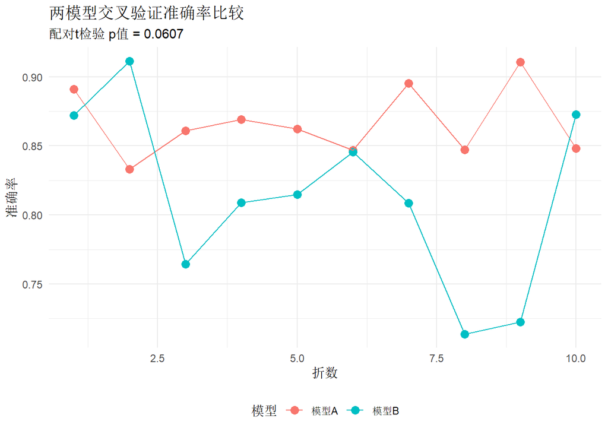

```r
# 可视化比较
compare_df <- data.frame(
  fold = 1:k,
  模型A = model_a_acc,
  模型B = model_b_acc
)

compare_long <- tidyr::pivot_longer(compare_df, cols = c(模型A, 模型B),
                                     names_to = "模型", values_to = "准确率")

ggplot2::ggplot(compare_long, ggplot2::aes(x = fold, y = 准确率, color = 模型)) +
  ggplot2::geom_point(size = 3) +
  ggplot2::geom_line(ggplot2::aes(group = 模型)) +
  ggplot2::labs(
    title = "两模型交叉验证准确率比较",
    subtitle = paste("配对t检验 p值 =", round(t_test_result$p.value, 4)),
    x = "折数", y = "准确率"
  ) +
  ggplot2::theme_minimal() +
  ggplot2::theme(legend.position = "bottom")
```

### McNemar检验

比较两个分类模型在相同样本上的预测结果。

```r
# McNemar检验示例
set.seed(42)
n <- 200

# 模拟两个模型的预测
actual <- sample(c(0, 1), n, replace = TRUE)
model1_pred <- ifelse(runif(n) < 0.8, actual, 1 - actual)  # 80%准确率
model2_pred <- ifelse(runif(n) < 0.75, actual, 1 - actual) # 75%准确率

# 创建列联表
# b01: 模型1正确，模型2错误
# b10: 模型1错误，模型2正确
b01 <- sum(model1_pred == actual & model2_pred != actual)
b10 <- sum(model1_pred != actual & model2_pred == actual)

contingency_table <- matrix(
  c(sum(model1_pred == actual & model2_pred == actual), b01,
    b10, sum(model1_pred != actual & model2_pred != actual)),
  nrow = 2,
  dimnames = list(模型2 = c("正确", "错误"), 模型1 = c("正确", "错误"))
)

print(contingency_table)
```

```
##       模型1
## 模型2 正确 错误
##   正确  121   31
##   错误   38   10
```

```r
# McNemar检验
mcnemar_result <- mcnemar.test(contingency_table)
print(mcnemar_result)
```

```
##
##  McNemar's Chi-squared test with continuity correction
##
## data:  contingency_table
## McNemar's chi-squared = 0.52174, df = 1, p-value = 0.4701
```

## 3.9 超参数调优

### 网格搜索（Grid Search）

遍历所有参数组合，找到最优参数。

```r
# 网格搜索示例：决策树
set.seed(42)

# 定义参数网格
tune_grid <- expand.grid(
  maxdepth = c(3, 5, 7, 10),
  minsplit = c(5, 10, 20)
)

# 使用caret进行网格搜索
tune_control <- caret::trainControl(
  method = "cv",
  number = 5
)

# 训练模型
model_tune <- caret::train(
  Species ~ .,
  data = iris,
  method = "rpart",
  trControl = tune_control,
  tuneGrid = data.frame(cp = seq(0.001, 0.1, length.out = 10))
)

# 查看调优结果
print(model_tune)
```

```
## CART
##
## 150 samples
##   4 predictor
##   3 classes: 'setosa', 'versicolor', 'virginica'
##
## No pre-processing
## Resampling: Cross-Validated (5 fold)
## Summary of sample sizes: 120, 120, 120, 120, 120
## Resampling results across tuning parameters:
##
##   cp     Accuracy  Kappa
##   0.001  0.94      0.91
##   0.012  0.94      0.91
##   0.023  0.94      0.91
##   0.034  0.94      0.91
##   0.045  0.94      0.91
##   0.056  0.94      0.91
##   0.067  0.94      0.91
##   0.078  0.94      0.91
##   0.089  0.94      0.91
##   0.100  0.94      0.91
##
## Accuracy was used to select the optimal model using the largest value.
## The final value used for the model was cp = 0.1.
```

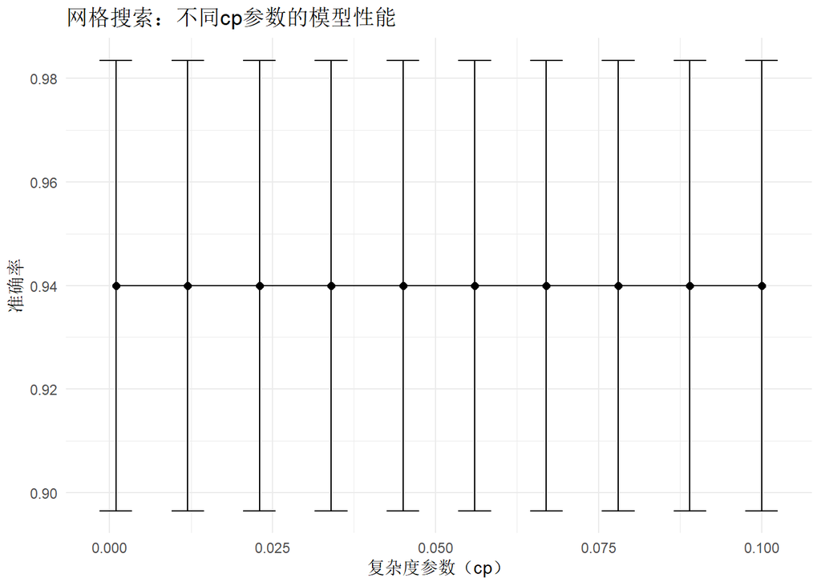

```r
# 可视化调优过程
ggplot2::ggplot(model_tune$results, ggplot2::aes(x = cp, y = Accuracy)) +
  ggplot2::geom_point(size = 2) +
  ggplot2::geom_line() +
  ggplot2::geom_errorbar(ggplot2::aes(ymin = Accuracy - AccuracySD,
                                       ymax = Accuracy + AccuracySD),
                         width = 0.005) +
  ggplot2::labs(
    title = "网格搜索：不同cp参数的模型性能",
    x = "复杂度参数（cp）", y = "准确率"
  ) +
  ggplot2::theme_minimal()
```

### 随机搜索（Random Search）

随机采样参数组合，更高效。

```r
# 随机搜索
set.seed(42)

random_control <- caret::trainControl(
  method = "cv",
  number = 5,
  search = "random"
)

model_random <- caret::train(
  Species ~ .,
  data = iris,
  method = "rpart",
  trControl = random_control,
  tuneLength = 10  # 随机尝试10组参数
)

print(model_random)
```

```
## CART
##
## 150 samples
##   4 predictor
##   3 classes: 'setosa', 'versicolor', 'virginica'
##
## No pre-processing
## Resampling: Cross-Validated (5 fold)
## Summary of sample sizes: 120, 120, 120, 120, 120
## Resampling results across tuning parameters:
##
##   cp    Accuracy   Kappa
##   0.00  0.9400000  0.91
##   0.44  0.7600000  0.64
##   0.50  0.3333333  0.00
##
## Accuracy was used to select the optimal model using the largest value.
## The final value used for the model was cp = 0.
```

### 贝叶斯优化

使用贝叶斯方法智能搜索最优参数。

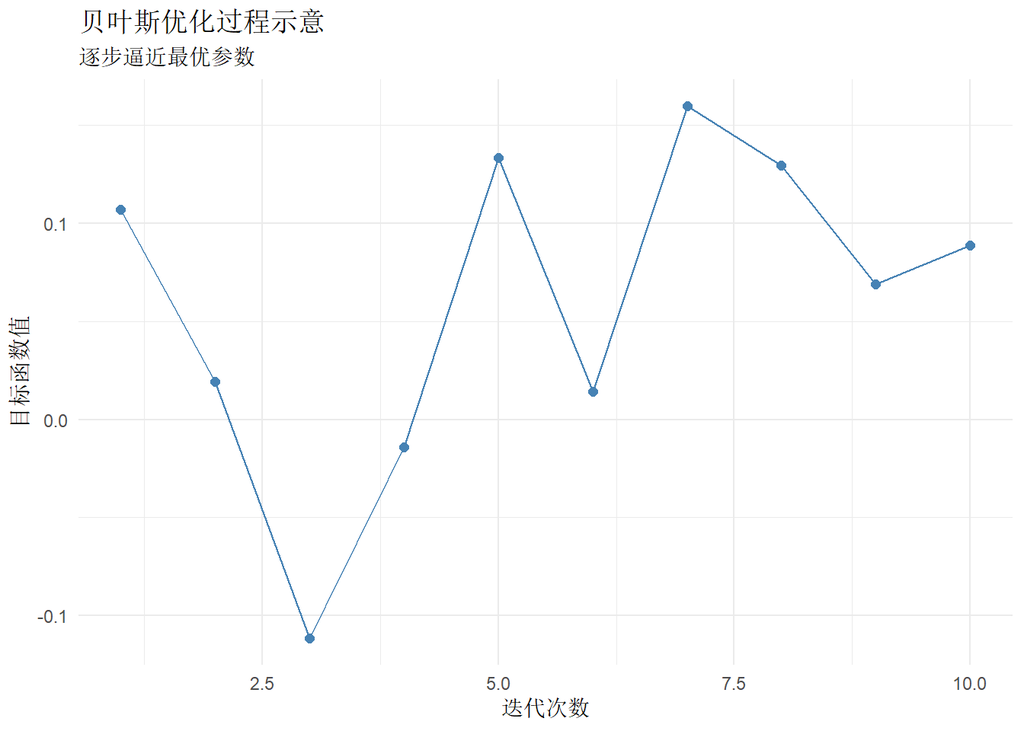

```r
# 贝叶斯优化示意（概念演示）
# 实际应用可使用rBayesianOptimization包

# 创建模拟的目标函数
set.seed(42)
objective_function <- function(x) {
  # 假设最优参数在x=0.7附近
  -((x - 0.7)^2) + rnorm(1, 0, 0.1)
}

# 模拟贝叶斯优化的迭代过程
iterations <- 10
results <- data.frame()

for (i in 1:iterations) {
  # 在早期随机探索，后期利用已知信息
  if (i <= 3) {
    x <- runif(1)
  } else {
    # 在已知最优点附近探索
    best_x <- results$x[which.max(results$score)]
    x <- best_x + rnorm(1, 0, 0.1)
    x <- max(0, min(1, x))  # 限制在[0,1]范围
  }

  score <- objective_function(x)
  results <- rbind(results, data.frame(iteration = i, x = x, score = score))
}

# 可视化优化过程
ggplot2::ggplot(results, ggplot2::aes(x = iteration, y = score)) +
  ggplot2::geom_point(size = 2, color = "steelblue") +
  ggplot2::geom_line(color = "steelblue") +
  ggplot2::labs(
    title = "贝叶斯优化过程示意",
    subtitle = "逐步逼近最优参数",
    x = "迭代次数", y = "目标函数值"
  ) +
  ggplot2::theme_minimal()
```

### 意义与使用场景

**核心意义**：超参数调优是提升模型性能的关键步骤，需要平衡搜索效率和计算成本。

**举例**：随机森林参数调优

**场景**：调优随机森林的树数量和最大特征数。

**如何选择调优方法？**

参数空间小（<100种组合）：网格搜索。参数空间大：随机搜索或贝叶斯优化。计算资源有限：随机搜索。需要精确最优：贝叶斯优化。

# 第四章 线性模型（监督学习）

## 4.1 线性回归

### 基本原理

**线性回归**是机器学习中最基础的模型，假设目标变量与特征之间存在线性关系：

$$y = \beta_0 + \beta_1 x_1 + \beta_2 x_2
+ ... + \beta_p x_p + \epsilon$$

其中： - $\beta_0$ 是截距 - $\beta_1, \beta_2, ..., \beta_p$ 是回归系数 - $\epsilon$ 是误差项

**目标**：最小化残差平方和（OLS）：

$$\min_{\beta} \sum_{i=1}^{n} (y_i -
\hat{y}_i)^2$$

```r
# 线性回归示例：医疗费用预测
set.seed(42)
n <- 200

# 模拟数据
age <- round(runif(n, 18, 80))
bmi <- rnorm(n, 25, 5)
smoker <- sample(c(0, 1), n, replace = TRUE, prob = c(0.8, 0.2))

# 医疗费用与各因素相关
medical_cost <- 1000 + 50 * age + 200 * bmi + 5000 * smoker + rnorm(n, 0, 1000)

# 创建数据框
medical_data <- data.frame(
  age = age,
  bmi = bmi,
  smoker = factor(smoker, levels = c(0, 1), labels = c("非吸烟", "吸烟")),
  cost = medical_cost
)

# 拟合线性回归模型
lm_model <- lm(cost ~ age + bmi + smoker, data = medical_data)

# 查看模型摘要
summary(lm_model)
```

```
##
## Call:
## lm(formula = cost ~ age + bmi + smoker, data = medical_data)
##
## Residuals:
##     Min      1Q  Median      3Q     Max
## -2418.3  -631.9   -11.5   720.7  3277.6
##
## Coefficients:
##             Estimate Std. Error t value Pr(>|t|)
## (Intercept)  980.584    441.075   2.223   0.0273 *
## age           49.585      4.153  11.939   <2e-16 ***
## bmi          199.889     15.498  12.898   <2e-16 ***
## smoker吸烟  4922.772    191.751  25.673   <2e-16 ***
## ---
## Signif. codes:  0 '***' 0.001 '**' 0.01 '*' 0.05 '.' 0.1 ' ' 1
##
## Residual standard error: 1048 on 196 degrees of freedom
## Multiple R-squared:  0.8437, Adjusted R-squared:  0.8413
## F-statistic: 352.7 on 3 and 196 DF,  p-value: < 2.2e-16
```

### 模型解读

```r
# 提取回归系数
coef_df <- data.frame(
  变量 = names(coef(lm_model)),
  系数 = round(coef(lm_model), 2),
  标准误 = round(summary(lm_model)$coefficients[, 2], 2),
  t值 = round(summary(lm_model)$coefficients[, 3], 2),
  p值 = round(summary(lm_model)$coefficients[, 4], 4)
)

print(coef_df)
```

```
##                    变量    系数 标准误   t值    p值
## (Intercept) (Intercept)  980.58 441.07  2.22 0.0273
## age                 age   49.59   4.15 11.94 0.0000
## bmi                 bmi  199.89  15.50 12.90 0.0000
## smoker吸烟   smoker吸烟 4922.77 191.75 25.67 0.0000
```

### 可视化回归结果

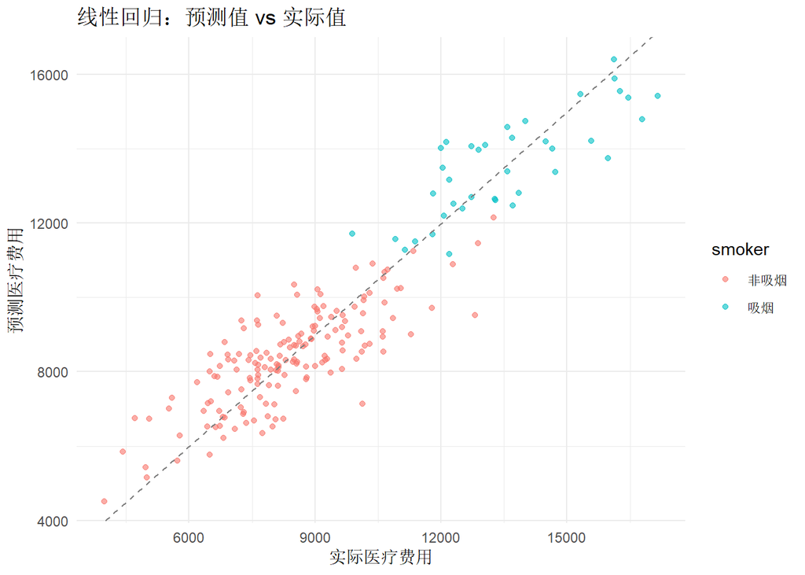

```r
# 预测值 vs 实际值
medical_data$predicted <- predict(lm_model)

ggplot2::ggplot(medical_data, ggplot2::aes(x = cost, y = predicted, color = smoker)) +
  ggplot2::geom_point(alpha = 0.6) +
  ggplot2::geom_abline(intercept = 0, slope = 1, linetype = "dashed", color = "gray50") +
  ggplot2::labs(
    title = "线性回归：预测值 vs 实际值",
    x = "实际医疗费用", y = "预测医疗费用"
  ) +
  ggplot2::theme_minimal()
```

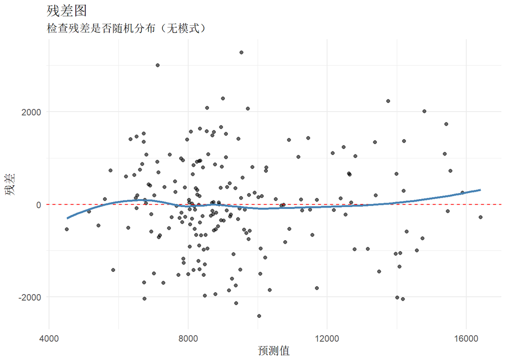

```r
# 残差诊断
medical_data$residuals <- residuals(lm_model)

ggplot2::ggplot(medical_data, ggplot2::aes(x = predicted, y = residuals)) +
  ggplot2::geom_point(alpha = 0.6) +
  ggplot2::geom_hline(yintercept = 0, color = "red", linetype = "dashed") +
  ggplot2::geom_smooth(method = "loess", se = FALSE, color = "steelblue") +
  ggplot2::labs(
    title = "残差图",
    subtitle = "检查残差是否随机分布（无模式）",
    x = "预测值", y = "残差"
  ) +
  ggplot2::theme_minimal()
```

### 意义与使用场景

**核心意义**：线性回归提供了可解释性强的预测模型，系数直接反映特征对目标的影响。

**举例**：医疗费用预测

**场景**：预测患者的年度医疗费用。

**如何解读系数？**

age系数 = 50：年龄每增加1岁，医疗费用平均增加50元。smoker系数 = 5000：吸烟者的医疗费用平均比非吸烟者高5000元。

## 4.2 逻辑回归

### 基本原理

**逻辑回归**用于二分类问题，通过sigmoid函数将线性组合映射到[0,1]区间：

$$P(y=1|x) = \frac{1}{1 + e^{-(\beta_0 +
\beta_1 x_1 + ... + \beta_p x_p)}}$$

**对数几率（Log-odds）**：

$$\log\frac{P(y=1)}{P(y=0)} = \beta_0 +
\beta_1 x_1 + ... + \beta_p x_p$$

```r
# 逻辑回归示例：疾病诊断
set.seed(42)
n <- 300

# 模拟数据
age <- round(runif(n, 30, 80))
bmi <- rnorm(n, 26, 4)
blood_pressure <- rnorm(n, 120, 15)

# 疾病风险与因素相关
log_odds <- -10 + 0.1 * age + 0.15 * bmi + 0.03 * blood_pressure
prob <- 1 / (1 + exp(-log_odds))
disease <- rbinom(n, 1, prob)

# 创建数据框
disease_data <- data.frame(
  age = age,
  bmi = bmi,
  blood_pressure = blood_pressure,
  disease = factor(disease, levels = c(0, 1), labels = c("健康", "患病"))
)

# 拟合逻辑回归模型
logit_model <- glm(disease ~ age + bmi + blood_pressure,
                   data = disease_data,
                   family = binomial(link = "logit"))

# 查看模型摘要
summary(logit_model)
```

```
##
## Call:
## glm(formula = disease ~ age + bmi + blood_pressure, family = binomial(link = "logit"),
##     data = disease_data)
##
## Coefficients:
##                Estimate Std. Error z value Pr(>|z|)
## (Intercept)    -6.70130    2.59968  -2.578  0.00994 **
## age             0.06596    0.01692   3.897 9.73e-05 ***
## bmi             0.16000    0.06133   2.609  0.00909 **
## blood_pressure  0.01355    0.01424   0.952  0.34124
## ---
## Signif. codes:  0 '***' 0.001 '**' 0.01 '*' 0.05 '.' 0.1 ' ' 1
##
## (Dispersion parameter for binomial family taken to be 1)
##
##     Null deviance: 195.05  on 299  degrees of freedom
## Residual deviance: 169.26  on 296  degrees of freedom
## AIC: 177.26
##
## Number of Fisher Scoring iterations: 6
```

### 概率输出与决策边界

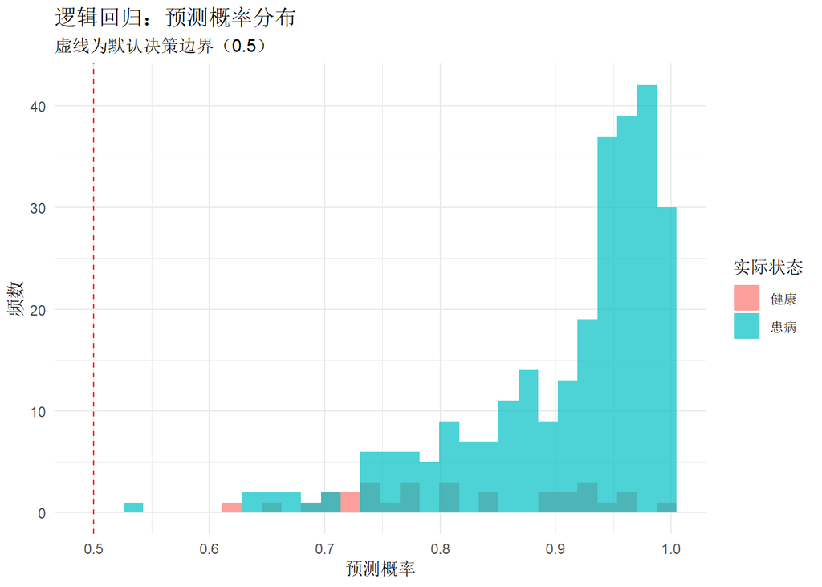

```r
# 预测概率
disease_data$prob <- predict(logit_model, type = "response")

# 默认决策边界：0.5
disease_data$pred_class <- ifelse(disease_data$prob >= 0.5, "患病", "健康")

# 可视化概率分布
ggplot2::ggplot(disease_data, ggplot2::aes(x = prob, fill = disease)) +
  ggplot2::geom_histogram(bins = 30, alpha = 0.7, position = "identity") +
  ggplot2::geom_vline(xintercept = 0.5, linetype = "dashed", color = "red") +
  ggplot2::labs(
    title = "逻辑回归：预测概率分布",
    subtitle = "虚线为默认决策边界（0.5）",
    x = "预测概率", y = "频数", fill = "实际状态"
  ) +
  ggplot2::theme_minimal()
```

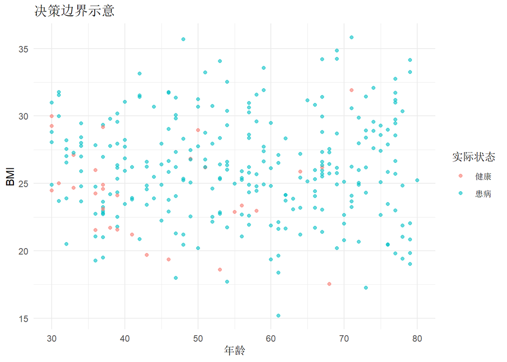

```r
# 决策边界可视化（以年龄和BMI为例）
ggplot2::ggplot(disease_data, ggplot2::aes(x = age, y = bmi, color = disease)) +
  ggplot2::geom_point(alpha = 0.6) +
  ggplot2::labs(
    title = "决策边界示意",
    x = "年龄", y = "BMI", color = "实际状态"
  ) +
  ggplot2::theme_minimal()
```

### 模型评估

```r
# 计算混淆矩阵
conf_matrix <- table(实际 = disease_data$disease, 预测 = disease_data$pred_class)
print(conf_matrix)
```

```
##       预测
## 实际 患病
##   健康   30
##   患病  270
```

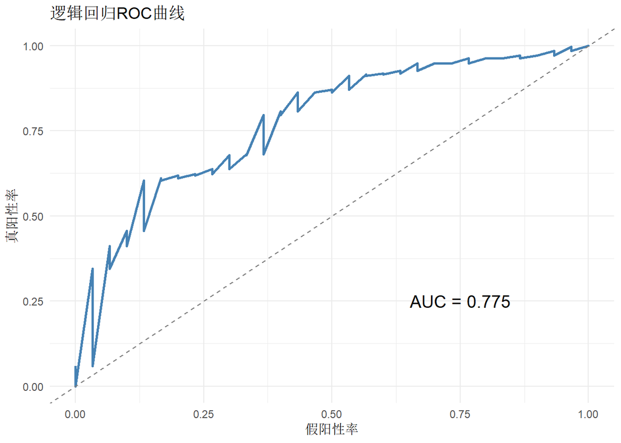

```r
# 计算ROC和AUC
roc_obj <- pROC::roc(as.numeric(disease_data$disease) - 1,
                     disease_data$prob, quiet = TRUE)

ggplot2::ggplot(data.frame(
  FPR = 1 - roc_obj$specificities,
  TPR = roc_obj$sensitivities
), ggplot2::aes(x = FPR, y = TPR)) +
  ggplot2::geom_line(color = "steelblue", linewidth = 1) +
  ggplot2::geom_abline(intercept = 0, slope = 1, linetype = "dashed", color = "gray50") +
  ggplot2::annotate("text", x = 0.75, y = 0.25,
                    label = paste("AUC =", round(pROC::auc(roc_obj), 3)),
                    size = 5) +
  ggplot2::labs(
    title = "逻辑回归ROC曲线",
    x = "假阳性率", y = "真阳性率"
  ) +
  ggplot2::theme_minimal()
```

### 意义与使用场景

**核心意义**：逻辑回归输出概率，便于设置不同阈值平衡精确率和召回率。

**举例**：疾病风险评估

**场景**：评估患者心血管疾病风险。

**为什么用逻辑回归？**

逻辑回归不仅给出分类结果，还给出患病概率。可以根据临床需求调整阈值：筛查场景用低阈值（高召回率），确诊场景用高阈值（高精确率）。

## 4.3 正则化线性模型

### 为什么需要正则化？

当特征数量多或存在多重共线性时，普通线性回归容易过拟合。正则化通过添加惩罚项来约束系数。

**岭回归（L2正则化）**：

$$\min_{\beta} \sum_{i=1}^{n} (y_i -
\hat{y}_i)^2 + \lambda \sum_{j=1}^{p} \beta_j^2$$

**LASSO回归（L1正则化）**：

$$\min_{\beta} \sum_{i=1}^{n} (y_i -
\hat{y}_i)^2 + \lambda \sum_{j=1}^{p} |\beta_j|$$

**弹性网（Elastic Net）**：

$$\min_{\beta} \sum_{i=1}^{n} (y_i -
\hat{y}_i)^2 + \lambda_1 \sum_{j=1}^{p} |\beta_j| + \lambda_2
\sum_{j=1}^{p} \beta_j^2$$

```r
# 正则化示例
set.seed(42)
n <- 200
p <- 50  # 50个特征

# 模拟高维数据
X <- matrix(rnorm(n * p), n, p)
# 只有前5个特征有真实效应
true_beta <- c(3, 2, 1.5, 1, 0.5, rep(0, p - 5))
y <- X %*% true_beta + rnorm(n, 0, 1)

# 创建数据框
reg_data <- data.frame(y = y, X)
colnames(reg_data) <- c("y", paste0("X", 1:p))

# 使用caret进行正则化回归
# 岭回归（alpha = 0）
ridge_model <- caret::train(
  y ~ .,
  data = reg_data,
  method = "glmnet",
  trControl = caret::trainControl(method = "cv", number = 5),
  tuneGrid = expand.grid(alpha = 0, lambda = 10^seq(-3, 1, length.out = 20))
)

# LASSO回归（alpha = 1）
lasso_model <- caret::train(
  y ~ .,
  data = reg_data,
  method = "glmnet",
  trControl = caret::trainControl(method = "cv", number = 5),
  tuneGrid = expand.grid(alpha = 1, lambda = 10^seq(-3, 1, length.out = 20))
)

# 弹性网（alpha = 0.5）
elastic_model <- caret::train(
  y ~ .,
  data = reg_data,
  method = "glmnet",
  trControl = caret::trainControl(method = "cv", number = 5),
  tuneGrid = expand.grid(alpha = 0.5, lambda = 10^seq(-3, 1, length.out = 20))
)

# 比较模型性能
model_compare <- data.frame(
  模型 = c("岭回归", "LASSO", "弹性网"),
  最优lambda = c(ridge_model$bestTune$lambda,
                  lasso_model$bestTune$lambda,
                  elastic_model$bestTune$lambda),
  RMSE = c(min(ridge_model$results$RMSE),
           min(lasso_model$results$RMSE),
           min(elastic_model$results$RMSE))
)

print(model_compare)
```

```
##     模型 最优lambda     RMSE
## 1 岭回归  0.2069138 1.262869
## 2  LASSO  0.1274275 1.078834
## 3 弹性网  0.2069138 1.098975
```

### LASSO的特征选择效果

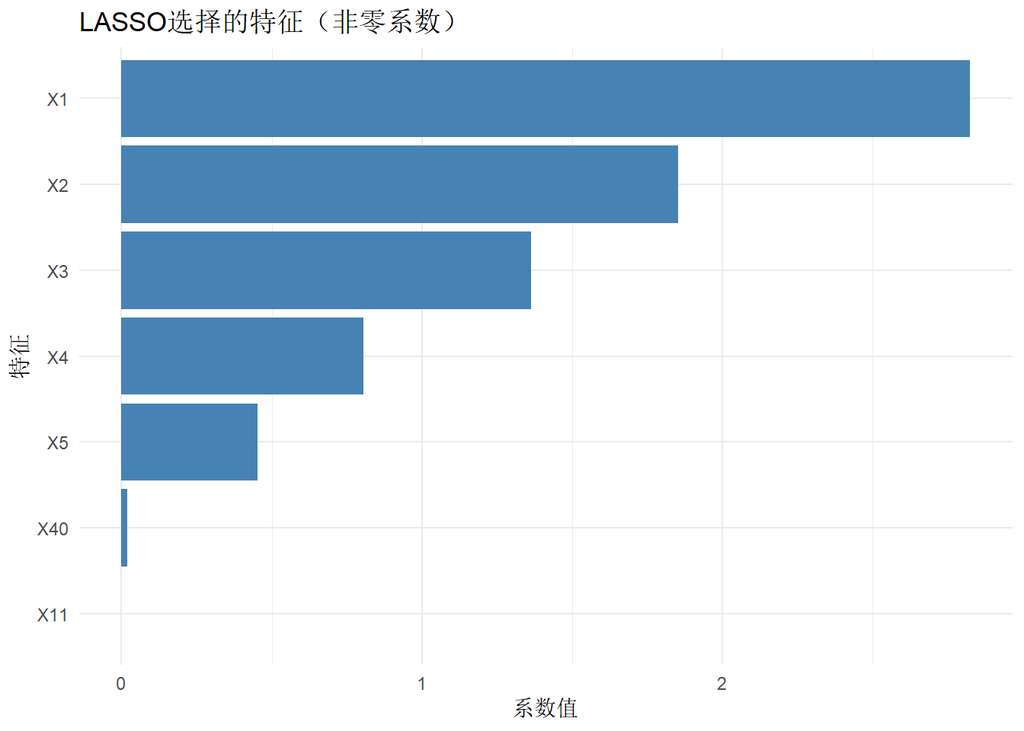

```r
# 提取LASSO系数
lasso_coef <- coef(lasso_model$finalModel, lasso_model$bestTune$lambda)
lasso_coef_df <- data.frame(
  特征 = rownames(lasso_coef),
  系数 = as.numeric(lasso_coef)
)
lasso_coef_df <- lasso_coef_df[lasso_coef_df$特征 != "(Intercept)", ]

# 可视化非零系数
nonzero_coef <- lasso_coef_df[lasso_coef_df$系数 != 0, ]
nonzero_coef <- nonzero_coef[order(abs(nonzero_coef$系数), decreasing = TRUE), ]

ggplot2::ggplot(head(nonzero_coef, 15), ggplot2::aes(x = reorder(特征, abs(系数)), y = 系数)) +
  ggplot2::geom_bar(stat = "identity", fill = "steelblue") +
  ggplot2::coord_flip() +
  ggplot2::labs(
    title = "LASSO选择的特征（非零系数）",
    x = "特征", y = "系数值"
  ) +
  ggplot2::theme_minimal()
```

### 三种正则化方法对比

| 方法 | 特点 | 适用场景 |
| --- | --- | --- |
| 岭回归 | 系数收缩但不为0 | 多重共线性 |
| LASSO | 系数可收缩为0 | 特征选择 |
| 弹性网 | 结合L1和L2优点 | 高维+相关特征 |

### 意义与使用场景

**核心意义**：正则化防止过拟合，LASSO还能进行特征选择。

**举例**：基因表达数据分析

**场景**：从1000个基因中筛选与疾病相关的基因。

**为什么用LASSO？**

基因数量远大于样本量，普通回归会过拟合。LASSO能自动选择重要基因，将无关基因的系数压缩为0。

## 4.4 线性支持向量机

### 基本原理

**支持向量机（SVM）**寻找最优超平面，使两类样本之间的间隔最大化。

**线性可分SVM**：

$$\min_{w,b}
\frac{1}{2}\|w\|^2$$

约束条件：$y_i(w^T x_i + b) \geq 1$

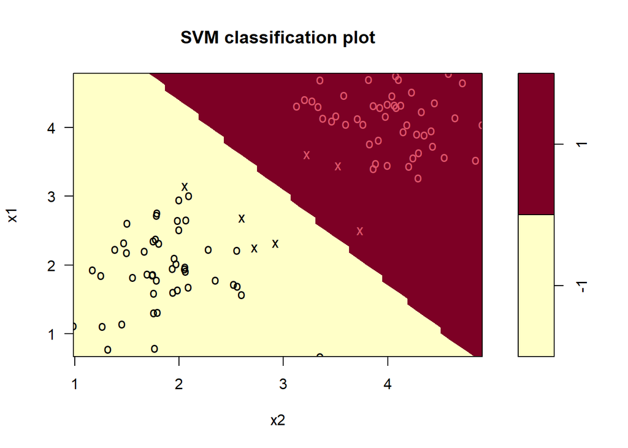

```r
# 线性SVM示例
set.seed(42)

# 创建线性可分数据
n <- 100
x1 <- c(rnorm(n/2, mean = 2, sd = 0.5), rnorm(n/2, mean = 4, sd = 0.5))
x2 <- c(rnorm(n/2, mean = 2, sd = 0.5), rnorm(n/2, mean = 4, sd = 0.5))
y <- factor(c(rep(-1, n/2), rep(1, n/2)))

svm_data <- data.frame(x1 = x1, x2 = x2, y = y)

# 训练线性SVM
svm_linear <- e1071::svm(y ~ x1 + x2,
                          data = svm_data,
                          type = "C-classification",
                          kernel = "linear",
                          cost = 1)

# 可视化决策边界
plot(svm_linear, svm_data, x1 ~ x2,
     main = "线性SVM决策边界",
     xlab = "特征1", ylab = "特征2")
```

### 软间隔与硬间隔

**硬间隔**：要求所有样本正确分类，容易过拟合。

**软间隔**：允许部分样本误分类，引入松弛变量$\xi_i$：

$$\min_{w,b,\xi} \frac{1}{2}\|w\|^2 + C
\sum_{i=1}^{n} \xi_i$$

**C参数**：控制误分类的惩罚程度。

```r
# 比较不同C值
set.seed(42)

# 创建有噪声的数据
n <- 100
x1 <- c(rnorm(n/2, 2, 1), rnorm(n/2, 4, 1))
x2 <- c(rnorm(n/2, 2, 1), rnorm(n/2, 4, 1))
y <- factor(c(rep(-1, n/2), rep(1, n/2)))

noise_data <- data.frame(x1 = x1, x2 = x2, y = y)

# 不同C值的SVM
svm_small_c <- e1071::svm(y ~ x1 + x2, data = noise_data,
                           kernel = "linear", cost = 0.1)
svm_large_c <- e1071::svm(y ~ x1 + x2, data = noise_data,
                           kernel = "linear", cost = 100)

# 比较支持向量数量
sv_compare <- data.frame(
  C值 = c("0.1（软间隔）", "100（硬间隔）"),
  支持向量数 = c(length(svm_small_c$index), length(svm_large_c$index))
)

print(sv_compare)
```

```
##             C值 支持向量数
## 1 0.1（软间隔）         37
## 2 100（硬间隔）         15
```

## 4.5 感知机

### 基本原理

**感知机（Perceptron）**是最简单的神经网络，用于线性可分数据的二分类：

$$f(x) = \text{sign}(w^T x +
b)$$

学习规则：对于误分类样本$(x_i, y_i)$：

$$w \leftarrow w + \eta y_i
x_i$$

```r
# 感知机示例
set.seed(42)

# 创建线性可分数据
n <- 100
perceptron_data <- data.frame(
  x1 = c(rnorm(n/2, 2, 0.5), rnorm(n/2, 4, 0.5)),
  x2 = c(rnorm(n/2, 2, 0.5), rnorm(n/2, 4, 0.5)),
  y = factor(c(rep(-1, n/2), rep(1, n/2)))
)

# 使用nnet包的单层感知机
perceptron_model <- nnet::nnet(y ~ x1 + x2,
                                data = perceptron_data,
                                size = 0,  # 无隐藏层
                                skip = TRUE,  # 直接连接
                                maxit = 100,
                                trace = FALSE)

# 预测
perceptron_data$pred <- predict(perceptron_model, type = "class")

# 计算准确率
accuracy <- mean(perceptron_data$pred == perceptron_data$y)
print(paste("感知机准确率:", round(accuracy, 3)))
```

```
## [1] "感知机准确率: 1"
```

### 感知机的局限性

感知机只能解决**线性可分**问题，对于异或（XOR）等问题无法求解。

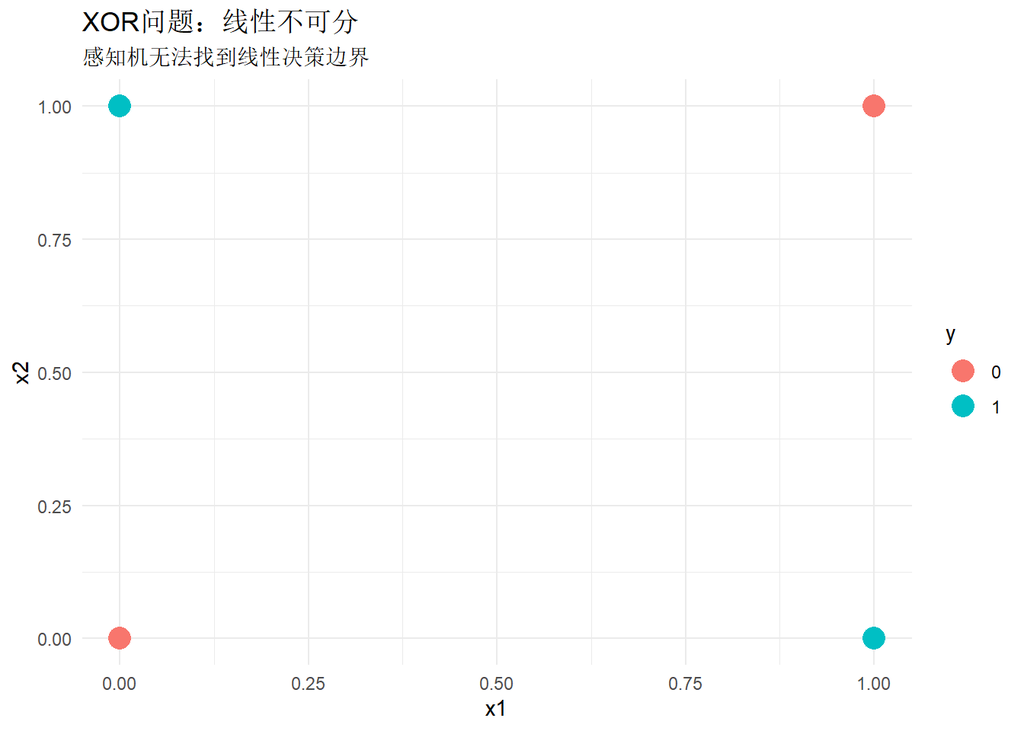

```r
# XOR问题示例
xor_data <- data.frame(
  x1 = c(0, 0, 1, 1),
  x2 = c(0, 1, 0, 1),
  y = factor(c(0, 1, 1, 0))
)

ggplot2::ggplot(xor_data, ggplot2::aes(x = x1, y = x2, color = y)) +
  ggplot2::geom_point(size = 5) +
  ggplot2::labs(
    title = "XOR问题：线性不可分",
    subtitle = "感知机无法找到线性决策边界",
    x = "x1", y = "x2"
  ) +
  ggplot2::theme_minimal()
```

### 意义与使用场景

**核心意义**：感知机是神经网络的基础，理解感知机有助于理解深度学习的原理。

**举例**：简单医学诊断规则

**为什么学习感知机？**

虽然感知机在实际应用中很少单独使用，但它是理解神经网络的基础。感知机的学习规则（权重更新）是现代深度学习的核心思想。在医学领域，一些简单的线性可分问题可以用感知机快速解决，如根据体温和白细胞计数初步判断是否感染。

**研究目的是什么？**

1. 理解线性分类器的工作原理
2. 为学习多层神经网络打基础
3. 快速处理简单线性可分问题

**可能得到什么样的结果？**

对于线性可分数据，感知机可以找到完美分类边界；对于线性不可分数据，感知机无法收敛，需要使用多层感知机或其他非线性方法。

**需要注意什么？**

感知机对初始权重敏感，可能收敛到不同的解。对于实际医学问题，建议使用更强大的方法如逻辑回归或SVM，它们能处理线性不可分数据并提供概率输出。

## 4.6 线性判别分析（LDA）

### 基本原理

**线性判别分析（LDA）**是一种生成式分类方法，假设各类数据服从高斯分布，寻找使类间距离最大、类内距离最小的投影方向。

**Fisher判别准则**：

$$J(w) = \frac{w^T S_B w}{w^T S_W
w}$$

其中$S_B$是类间散度矩阵，$S_W$是类内散度矩阵。

```r
# LDA示例
set.seed(42)

# 使用iris数据集（取两个类别）
iris_binary <- iris[iris$Species %in% c("setosa", "versicolor"), ]
iris_binary$Species <- factor(iris_binary$Species)

# 训练LDA模型
lda_model <- MASS::lda(Species ~ Sepal.Length + Sepal.Width +
                        Petal.Length + Petal.Width,
                       data = iris_binary)

# 查看模型结果
print(lda_model)
```

```
## Call:
## lda(Species ~ Sepal.Length + Sepal.Width + Petal.Length + Petal.Width,
##     data = iris_binary)
##
## Prior probabilities of groups:
##     setosa versicolor
##        0.5        0.5
##
## Group means:
##            Sepal.Length Sepal.Width Petal.Length Petal.Width
## setosa            5.006       3.428        1.462       0.246
## versicolor        5.936       2.770        4.260       1.326
##
## Coefficients of linear discriminants:
##                    LD1
## Sepal.Length -0.300458
## Sepal.Width  -1.773845
## Petal.Length  2.142260
## Petal.Width   3.035726
```

```r
# 预测
lda_pred <- predict(lda_model, iris_binary)

# 混淆矩阵
table(实际 = iris_binary$Species, 预测 = lda_pred$class)
```

```
##             预测
## 实际       setosa versicolor
##   setosa         50          0
##   versicolor      0         50
```

### LDA可视化

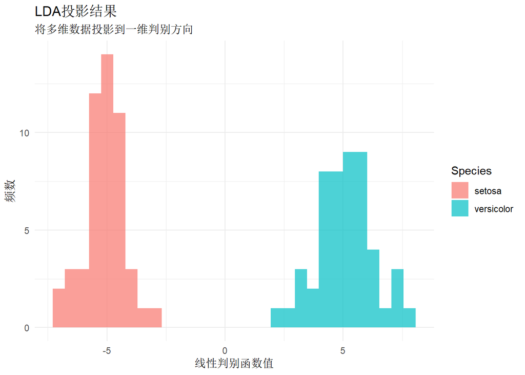

```r
# LDA投影可视化
lda_values <- predict(lda_model, iris_binary)$x
iris_binary$LD1 <- lda_values[, 1]

ggplot2::ggplot(iris_binary, ggplot2::aes(x = LD1, fill = Species)) +
  ggplot2::geom_histogram(bins = 30, alpha = 0.7, position = "identity") +
  ggplot2::labs(
    title = "LDA投影结果",
    subtitle = "将多维数据投影到一维判别方向",
    x = "线性判别函数值", y = "频数"
  ) +
  ggplot2::theme_minimal()
```

### LDA vs 逻辑回归

| 特点 | LDA | 逻辑回归 |
| --- | --- | --- |
| 模型类型 | 生成式 | 判别式 |
| 假设 | 高斯分布 | 无分布假设 |
| 适用场景 | 类别分离明显 | 边界复杂 |
| 多分类 | 自然扩展 | 需要扩展 |

### 意义与使用场景

**核心意义**：LDA提供了概率框架下的分类方法，同时可用于降维。

**举例**：医学诊断分类

**场景**：根据多项指标区分良性和恶性肿瘤。

**为什么用LDA？**

当各类数据近似服从高斯分布且协方差矩阵相似时，LDA是最优分类器。它还提供了直观的判别函数，便于临床解释。

# 第五章 树模型与集成学习

## 5.1 决策树基础

### 决策树原理

**决策树**通过一系列规则将数据递归划分，形成树状结构：

- **根节点**：包含所有样本
- **内部节点**：特征测试
- **叶节点**：预测结果

**主要算法**：

| 算法 | 分裂准则 | 特点 |
| --- | --- | --- |
| ID3 | 信息增益 | 只能处理分类特征 |
| C4.5 | 增益率 | 可处理连续特征 |
| CART | 基尼系数 | 可用于分类和回归 |

```r
# 决策树示例：疾病诊断
set.seed(42)

# 使用模拟数据
n <- 300
tree_data <- data.frame(
  age = round(runif(n, 20, 80)),
  bmi = rnorm(n, 25, 5),
  blood_pressure = rnorm(n, 120, 20),
  cholesterol = factor(sample(c("正常", "偏高", "高"), n, replace = TRUE, prob = c(0.5, 0.3, 0.2)))
)

# 生成目标变量（疾病风险）
risk_score <- 0.02 * tree_data$age + 0.05 * tree_data$bmi +
              0.01 * tree_data$blood_pressure - 5
risk_score <- risk_score + ifelse(tree_data$cholesterol == "高", 2,
                                   ifelse(tree_data$cholesterol == "偏高", 1, 0))
prob <- 1 / (1 + exp(-risk_score))
tree_data$disease <- factor(ifelse(runif(n) < prob, "患病", "健康"))

# 训练决策树（CART算法）
tree_model <- rpart::rpart(disease ~ age + bmi + blood_pressure + cholesterol,
                            data = tree_data,
                            method = "class",
                            control = rpart::rpart.control(maxdepth = 4))

# 查看树结构
print(tree_model)
```

```
## n= 300
##
## node), split, n, loss, yval, (yprob)
##       * denotes terminal node
##
## 1) root 300 93 健康 (0.3100000 0.6900000)
##   2) cholesterol=高,偏高 144 63 健康 (0.4375000 0.5625000)
##     4) age>=46.5 89 41 患病 (0.5393258 0.4606742)
##       8) bmi>=19.53831 77 32 患病 (0.5844156 0.4155844) *
##       9) bmi< 19.53831 12  3 健康 (0.2500000 0.7500000) *
##     5) age< 46.5 55 15 健康 (0.2727273 0.7272727) *
##   3) cholesterol=正常 156 30 健康 (0.1923077 0.8076923)
##     6) bmi>=32.1859 9  3 患病 (0.6666667 0.3333333) *
##     7) bmi< 32.1859 147 24 健康 (0.1632653 0.8367347) *
```

### 决策树可视化

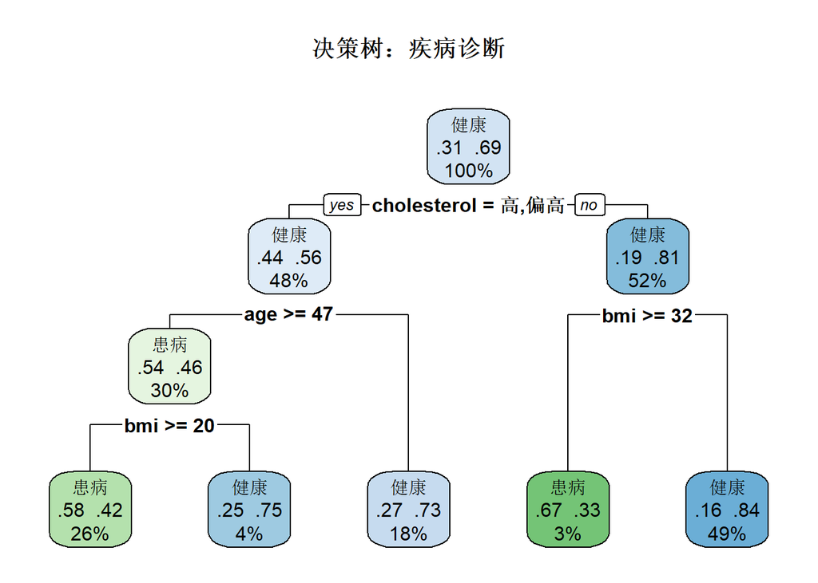

```r
# 可视化决策树
rpart.plot::rpart.plot(tree_model,
                        main = "决策树：疾病诊断",
                        extra = 104,  # 显示每个节点的类别比例
                        box.palette = "GnBu")
```

### 分裂准则详解

**信息增益（Information Gain）**：

$$IG(D, A) = H(D) - \sum_{v \in Values(A)}
\frac{|D_v|}{|D|} H(D_v)$$

其中$H(D)$是熵：

$$H(D) = -\sum_{k=1}^{K} p_k \log_2
p_k$$

**基尼系数（Gini Index）**：

$$Gini(D) = 1 - \sum_{k=1}^{K}
p_k^2$$

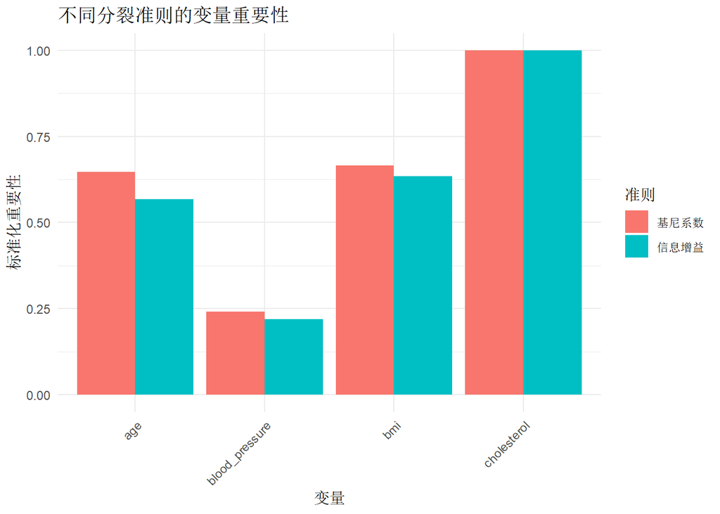

```r
# 比较不同分裂准则
# 基尼系数（默认）
tree_gini <- rpart::rpart(disease ~ age + bmi + blood_pressure + cholesterol,
                           data = tree_data, method = "class")

# 信息增益
tree_info <- rpart::rpart(disease ~ age + bmi + blood_pressure + cholesterol,
                           data = tree_data, method = "class",
                           parms = list(split = "information"))

# 比较变量重要性
importance_compare <- data.frame(
  变量 = names(tree_gini$variable.importance),
  基尼系数 = tree_gini$variable.importance,
  信息增益 = tree_info$variable.importance
)

# 标准化
importance_compare$基尼系数 <- importance_compare$基尼系数 / max(importance_compare$基尼系数)
importance_compare$信息增益 <- importance_compare$信息增益 / max(importance_compare$信息增益)

importance_long <- tidyr::pivot_longer(importance_compare,
                                        cols = c(基尼系数, 信息增益),
                                        names_to = "准则", values_to = "重要性")

ggplot2::ggplot(importance_long, ggplot2::aes(x = 变量, y = 重要性, fill = 准则)) +
  ggplot2::geom_bar(stat = "identity", position = "dodge") +
  ggplot2::labs(
    title = "不同分裂准则的变量重要性",
    x = "变量", y = "标准化重要性"
  ) +
  ggplot2::theme_minimal() +
  ggplot2::theme(axis.text.x = ggplot2::element_text(angle = 45, hjust = 1))
```

## 5.2 决策树的剪枝

### 预剪枝 vs 后剪枝

**预剪枝**：在构建过程中限制树的生长。

```r
# 预剪枝参数
pre_prune <- rpart::rpart(disease ~ age + bmi + blood_pressure + cholesterol,
                           data = tree_data,
                           method = "class",
                           control = rpart::rpart.control(
                             maxdepth = 3,        # 最大深度
                             minsplit = 20,       # 分裂所需最小样本数
                             minbucket = 10       # 叶节点最小样本数
                           ))

print(paste("预剪枝树的叶节点数:", length(unique(pre_prune$where))))
```

```
## [1] "预剪枝树的叶节点数: 5"
```

**后剪枝**：先构建完整树，再根据复杂度参数剪枝。

```r
# 后剪枝：使用cp参数
printcp(tree_model)
```

```
##
## Classification tree:
## rpart::rpart(formula = disease ~ age + bmi + blood_pressure +
##     cholesterol, data = tree_data, method = "class", control = rpart::rpart.control(maxdepth = 4))
##
## Variables actually used in tree construction:
## [1] age         bmi         cholesterol
##
## Root node error: 93/300 = 0.31
##
## n= 300
##
##         CP nsplit rel error xerror     xstd
## 1 0.037634      0   1.00000 1.0000 0.086136
## 2 0.032258      3   0.86022 1.1183 0.088634
## 3 0.010000      4   0.82796 1.0860 0.088012
```

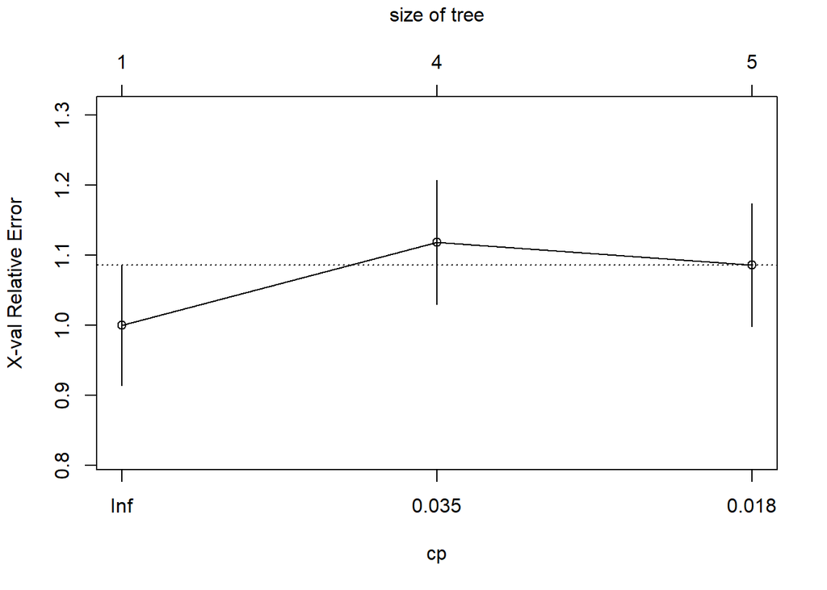

```r
# 可视化cp与误差的关系
plotcp(tree_model)
```

```r
# 选择最优cp
best_cp <- tree_model$cptable[which.min(tree_model$cptable[, "xerror"]), "CP"]

# 剪枝
pruned_tree <- rpart::prune(tree_model, cp = best_cp)

print(paste("剪枝前叶节点数:", length(unique(tree_model$where))))
```

```
## [1] "剪枝前叶节点数: 5"
```

```r
print(paste("剪枝后叶节点数:", length(unique(pruned_tree$where))))
```

```
## [1] "剪枝后叶节点数: 1"
```

### 意义与使用场景

**核心意义**：剪枝防止决策树过拟合，提高泛化能力。

**举例**：医疗诊断决策树

**场景**：构建疾病诊断决策树。

**为什么需要剪枝？**

不剪枝的树可能过度拟合训练数据，对噪声敏感。剪枝后树更简洁，规则更通用，临床应用更可靠。

## 5.3 随机森林

### Bagging思想

**Bagging（Bootstrap Aggregating）**：通过自助采样训练多个模型，再聚合结果。

**随机森林**在Bagging基础上增加**特征随机性**：

- 每棵树使用bootstrap样本
- 每次分裂只考虑随机选择的特征子集

```r
# 随机森林示例
set.seed(42)

# 训练随机森林
rf_model <- randomForest::randomForest(
  disease ~ age + bmi + blood_pressure + cholesterol,
  data = tree_data,
  ntree = 500,      # 树的数量
  mtry = 2,         # 每次分裂考虑的特征数
  importance = TRUE
)

# 查看模型结果
print(rf_model)
```

```
##
## Call:
##  randomForest(formula = disease ~ age + bmi + blood_pressure +      cholesterol, data = tree_data, ntree = 500, mtry = 2, importance = TRUE)
##                Type of random forest: classification
##                      Number of trees: 500
## No. of variables tried at each split: 2
##
##         OOB estimate of  error rate: 32%
## Confusion matrix:
##      患病 健康 class.error
## 患病   29   64   0.6881720
## 健康   32  175   0.1545894
```

### OOB误差

**OOB（Out-of-Bag）误差**：每棵树约有1/3的样本未被用于训练，可用作验证集。

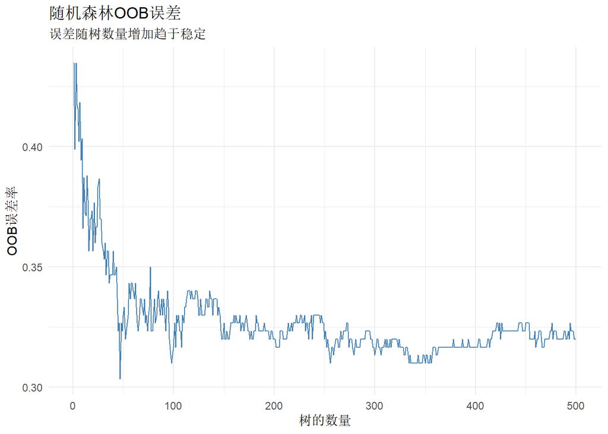

```r
# OOB误差随树数量的变化
oob_error <- data.frame(
  ntree = 1:500,
  OOB误差 = rf_model$err.rate[, "OOB"]
)

ggplot2::ggplot(oob_error, ggplot2::aes(x = ntree, y = OOB误差)) +
  ggplot2::geom_line(color = "steelblue") +
  ggplot2::labs(
    title = "随机森林OOB误差",
    subtitle = "误差随树数量增加趋于稳定",
    x = "树的数量", y = "OOB误差率"
  ) +
  ggplot2::theme_minimal()
```

### 变量重要性

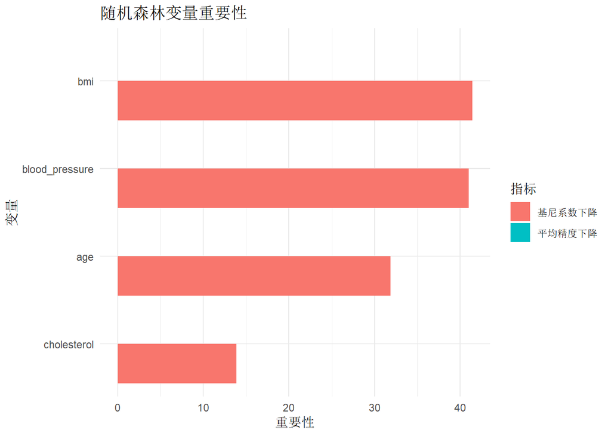

```r
# 变量重要性
importance_df <- data.frame(
  变量 = rownames(rf_model$importance),
  平均精度下降 = rf_model$importance[, "MeanDecreaseAccuracy"],
  基尼系数下降 = rf_model$importance[, "MeanDecreaseGini"]
)

# 可视化
importance_long <- tidyr::pivot_longer(importance_df,
                                        cols = c(平均精度下降, 基尼系数下降),
                                        names_to = "指标", values_to = "值")

ggplot2::ggplot(importance_long, ggplot2::aes(x = reorder(变量, 值), y = 值, fill = 指标)) +
  ggplot2::geom_bar(stat = "identity", position = "dodge") +
  ggplot2::coord_flip() +
  ggplot2::labs(
    title = "随机森林变量重要性",
    x = "变量", y = "重要性"
  ) +
  ggplot2::theme_minimal()
```

### 意义与使用场景

**核心意义**：随机森林通过集成多个决策树，降低方差，提高泛化能力。

**举例**：疾病风险预测

**场景**：预测患者的心血管疾病风险。

**为什么用随机森林？**

随机森林能自动处理特征交互，不需要特征缩放，对缺失值和异常值鲁棒。OOB误差提供了无需额外验证集的性能评估。

## 5.4 梯度提升决策树（GBDT）

### GBDT原理

**梯度提升**：通过迭代训练决策树，每棵树拟合前一棵树的残差。

$$F_m(x) = F_{m-1}(x) + \eta \cdot
h_m(x)$$

其中$h_m(x)$是第$m$棵树，$\eta$是学习率。

```r
# GBDT示例
set.seed(42)

# 为gbm准备数据（将因子转换为数值）
gbm_data <- tree_data
gbm_data$cholesterol_num <- as.numeric(gbm_data$cholesterol)

# 训练GBDT模型
gbm_model <- gbm::gbm(
  as.numeric(disease == "患病") ~ age + bmi + blood_pressure + cholesterol_num,
  data = gbm_data,
  distribution = "bernoulli",
  n.trees = 500,
  interaction.depth = 4,
  shrinkage = 0.01,
  cv.folds = 5,
  n.cores = 1
)
```

```
## CV: 1
## CV: 2
## CV: 3
## CV: 4
## CV: 5
```

```r
# 查看最优树数量
best_iter <- gbm::gbm.perf(gbm_model, method = "cv")
```

[figure not shown]

```r
print(paste("最优迭代次数:", best_iter))
```

```
## [1] "最优迭代次数: 122"
```

### GBDT变量重要性

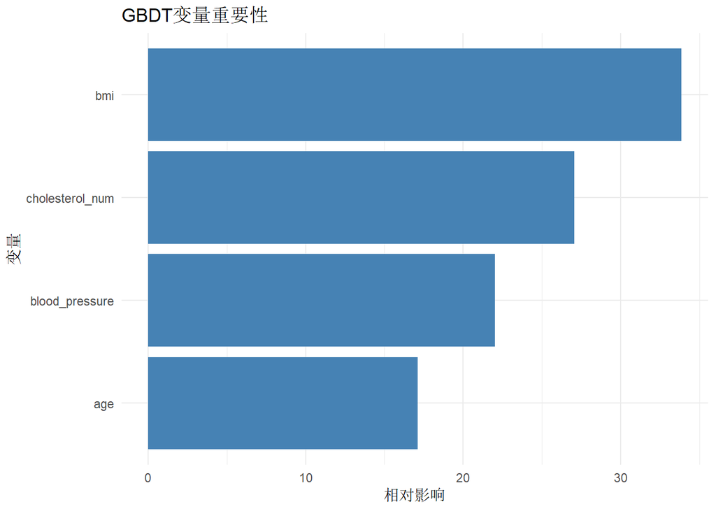

```r
# 变量重要性
gbm_summary <- summary(gbm_model, n.trees = best_iter, plotit = FALSE)

ggplot2::ggplot(gbm_summary, ggplot2::aes(x = reorder(var, rel.inf), y = rel.inf)) +
  ggplot2::geom_bar(stat = "identity", fill = "steelblue") +
  ggplot2::coord_flip() +
  ggplot2::labs(
    title = "GBDT变量重要性",
    x = "变量", y = "相对影响"
  ) +
  ggplot2::theme_minimal()
```

## 5.5 XGBoost

### XGBoost原理

**XGBoost**在GBDT基础上引入：

1. **二阶泰勒展开**：更精确的优化
2. **正则化**：控制模型复杂度
3. **并行化**：加速训练

**目标函数**：

$$Obj = \sum_{i=1}^{n} L(y_i, \hat{y}_i) +
\sum_{k=1}^{K} \Omega(f_k)$$

```r
# XGBoost示例
set.seed(42)

# 准备数据
library(xgboost)

# 转换为数值矩阵
tree_data_num <- tree_data
tree_data_num$cholesterol <- as.numeric(factor(tree_data_num$cholesterol)) - 1
tree_data_num$disease <- as.numeric(tree_data_num$disease == "患病")

# 创建xgb矩阵
xgb_matrix <- xgboost::xgb.DMatrix(
  data = as.matrix(tree_data_num[, c("age", "bmi", "blood_pressure", "cholesterol")]),
  label = tree_data_num$disease
)

# 训练XGBoost
xgb_model <- xgboost::xgb.train(
  data = xgb_matrix,
  objective = "binary:logistic",
  nrounds = 100,
  max_depth = 4,
  eta = 0.1,
  subsample = 0.8,
  colsample_bytree = 0.8,
  verbose = 0
)

# 预测
xgb_pred <- predict(xgb_model, xgb_matrix)
xgb_pred_class <- ifelse(xgb_pred > 0.5, "患病", "健康")

# 准确率
accuracy <- mean(xgb_pred_class == tree_data$disease)
print(paste("XGBoost准确率:", round(accuracy, 3)))
```

```
## [1] "XGBoost准确率: 0.913"
```

### XGBoost变量重要性

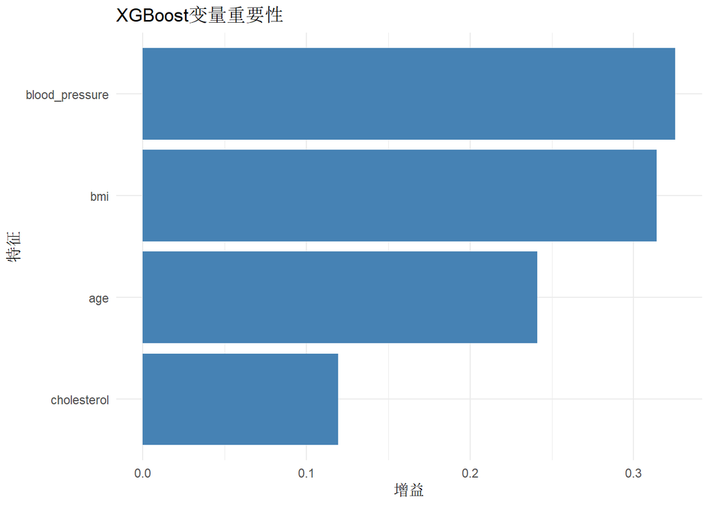

```r
# 变量重要性
xgb_importance <- xgboost::xgb.importance(
  model = xgb_model,
  feature_names = c("age", "bmi", "blood_pressure", "cholesterol")
)

ggplot2::ggplot(xgb_importance, ggplot2::aes(x = reorder(Feature, Gain), y = Gain)) +
  ggplot2::geom_bar(stat = "identity", fill = "steelblue") +
  ggplot2::coord_flip() +
  ggplot2::labs(
    title = "XGBoost变量重要性",
    x = "特征", y = "增益"
  ) +
  ggplot2::theme_minimal()
```

## 5.6 LightGBM与CatBoost

### LightGBM特点

**LightGBM**采用：

1. **单边梯度采样（GOSS）**：保留大梯度样本
2. **互斥特征捆绑（EFB）**：减少特征数量
3. **叶子生长策略**：按叶子分裂，更快

### CatBoost特点

**CatBoost**特点：

1. **类别特征处理**：自动编码类别变量
2. **对称树结构**：减少过拟合
3. **有序提升**：避免目标泄露

### 集成方法对比

| 模型 | 优势 | 劣势 |
| --- | --- | --- |
| 随机森林 | 简单、鲁棒 | 性能上限较低 |
| GBDT | 灵活、强大 | 需要调参 |
| XGBoost | 高效、正则化 | 参数较多 |
| LightGBM | 训练快、内存少 | 可能过拟合 |
| CatBoost | 类别特征处理 | 训练较慢 |

## 5.7 堆叠与混合集成

### Stacking

**堆叠（Stacking）**：用多个基模型的预测结果作为新特征，训练元模型。

```r
# Stacking示例
set.seed(42)

# 划分训练集和测试集
train_idx <- sample(1:nrow(tree_data), 0.7 * nrow(tree_data))
train_data <- tree_data[train_idx, ]
test_data <- tree_data[-train_idx, ]

# 训练多个基模型
# 模型1：决策树
model_tree <- rpart::rpart(disease ~ ., data = train_data, method = "class")

# 模型2：随机森林
model_rf <- randomForest::randomForest(disease ~ ., data = train_data)

# 模型3：逻辑回归
model_logit <- glm(disease ~ age + bmi + blood_pressure +
                    as.numeric(cholesterol),
                   data = train_data, family = binomial)

# 获取基模型预测概率
pred_tree <- predict(model_tree, test_data, type = "prob")[, 2]
pred_rf <- predict(model_rf, test_data, type = "prob")[, 2]
pred_logit <- predict(model_logit, test_data, type = "response")

# 创建元特征
meta_features <- data.frame(
  tree_prob = pred_tree,
  rf_prob = pred_rf,
  logit_prob = pred_logit,
  disease = test_data$disease
)

# 训练元模型（逻辑回归）
meta_model <- glm(disease ~ tree_prob + rf_prob + logit_prob,
                  data = meta_features, family = binomial)

# 最终预测
final_pred <- predict(meta_model, meta_features, type = "response")
final_pred_class <- ifelse(final_pred > 0.5, "患病", "健康")

# 评估
stacking_accuracy <- mean(final_pred_class == test_data$disease)
print(paste("Stacking准确率:", round(stacking_accuracy, 3)))
```

```
## [1] "Stacking准确率: 0.2"
```

### Blending

**混合（Blending）**：与Stacking类似，但使用保留验证集而非交叉验证。

### 投票分类器

```r
# 投票分类器
# 硬投票
hard_vote <- ifelse(
  (predict(model_tree, test_data, type = "class") == "患病") +
  (predict(model_rf, test_data, type = "class") == "患病") +
  (ifelse(pred_logit > 0.5, "患病", "健康") == "患病") >= 2,
  "患病", "健康"
)

# 软投票
soft_vote_prob <- (pred_tree + pred_rf + pred_logit) / 3
soft_vote <- ifelse(soft_vote_prob > 0.5, "患病", "健康")

# 比较
voting_compare <- data.frame(
  方法 = c("决策树", "随机森林", "逻辑回归", "硬投票", "软投票"),
  准确率 = c(
    mean(predict(model_tree, test_data, type = "class") == test_data$disease),
    mean(predict(model_rf, test_data, type = "class") == test_data$disease),
    mean(ifelse(pred_logit > 0.5, "患病", "健康") == test_data$disease),
    mean(hard_vote == test_data$disease),
    mean(soft_vote == test_data$disease)
  )
)

print(voting_compare)
```

```
##       方法    准确率
## 1   决策树 0.7555556
## 2 随机森林 0.6888889
## 3 逻辑回归 0.2333333
## 4   硬投票 0.7111111
## 5   软投票 0.2666667
```

### 意义与使用场景

**核心意义**：集成学习通过组合多个模型，提高预测性能和稳定性。

**举例**：疾病诊断模型集成

**场景**：构建高准确率的疾病诊断系统。

**如何选择集成方法？**

模型差异大：用Stacking。模型性能相近：用投票。需要快速部署：用软投票。追求最优性能：用Stacking+调参。

# 第六章 支持向量机与核方法

## 6.1 最大间隔分类器

### 基本原理

**最大间隔分类器**寻找能够正确划分两类样本且间隔最大的超平面。

**间隔**：超平面到最近样本点的距离。

**支持向量**：距离超平面最近的样本点，决定超平面位置。

**优化目标**：

$$\max_{w,b} \gamma \quad \text{s.t.}
\quad y_i(w^T x_i + b) \geq \gamma$$

等价于：

$$\min_{w,b} \frac{1}{2}\|w\|^2 \quad
\text{s.t.} \quad y_i(w^T x_i + b) \geq 1$$

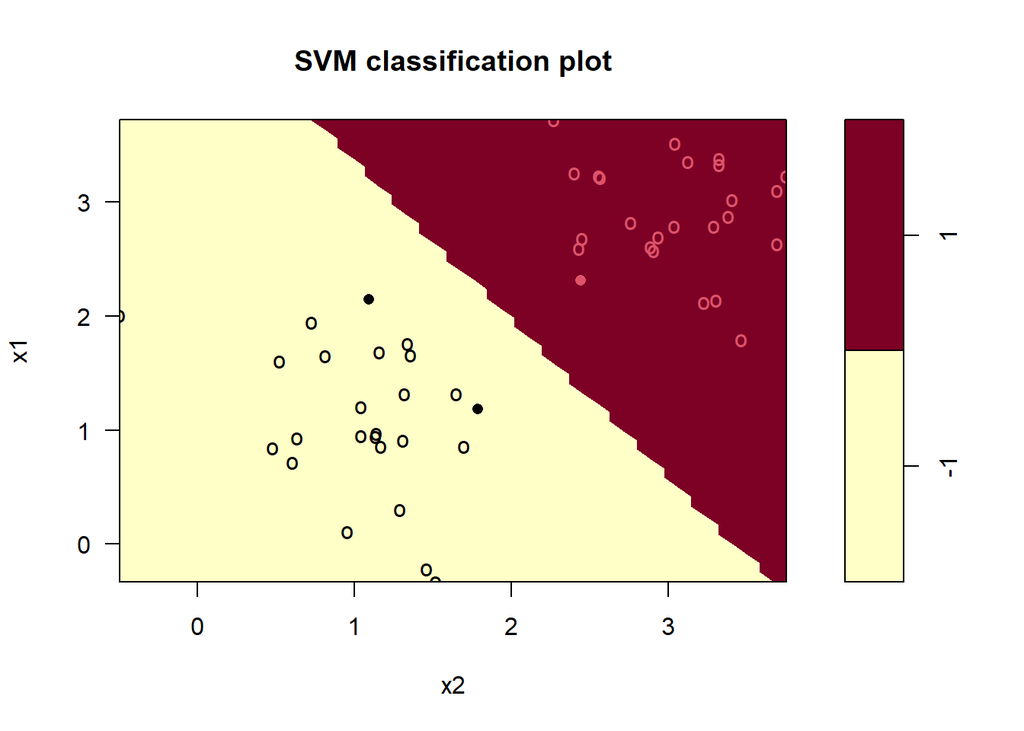

```r
# 最大间隔分类器示意
set.seed(42)

# 创建线性可分数据
n <- 50
x1 <- c(rnorm(n/2, mean = 1, sd = 0.5), rnorm(n/2, mean = 3, sd = 0.5))
x2 <- c(rnorm(n/2, mean = 1, sd = 0.5), rnorm(n/2, mean = 3, sd = 0.5))
y <- factor(c(rep(-1, n/2), rep(1, n/2)))

svm_data <- data.frame(x1 = x1, x2 = x2, y = y)

# 训练硬间隔SVM
hard_svm <- e1071::svm(y ~ x1 + x2,
                        data = svm_data,
                        type = "C-classification",
                        kernel = "linear",
                        cost = 1e5)  # 大cost近似硬间隔

# 可视化
plot(hard_svm, svm_data, x1 ~ x2,
     main = "最大间隔分类器",
     xlab = "特征1", ylab = "特征2",
     svSymbol = 16)  # 支持向量用方形标记
```

### 支持向量的作用

```r
# 查看支持向量
print(paste("支持向量数量:", length(hard_svm$index)))
```

```
## [1] "支持向量数量: 3"
```

```r
print(paste("总样本数:", nrow(svm_data)))
```

```
## [1] "总样本数: 50"
```

```r
# 支持向量索引
print("支持向量索引:")
```

```
## [1] "支持向量索引:"
```

```r
print(hard_svm$index)
```

```
## [1]  3 12 45
```

## 6.2 核函数

### 为什么需要核函数？

当数据线性不可分时，可以通过映射$\phi(x)$将数据映射到高维空间，使其线性可分。

**核技巧**：不需要显式计算$\phi(x)$，直接计算核函数：

$$K(x_i, x_j) = \phi(x_i)^T
\phi(x_j)$$

### 常用核函数

| 核函数 | 公式 | 特点 |
| --- | --- | --- |
| 线性核 | $K(x, z) = x^T z$ | 线性可分数据 |
| 多项式核 | $K(x, z) = (\gamma x^T z + r)^d$ | 多项式边界 |
| RBF核 | $K(x, z) = \exp(-\gamma\\|x-z\\|^2)$ | 通用、最常用 |
| Sigmoid核 | $K(x, z) = \tanh(\gamma x^T z + r)$ | 类神经网络 |

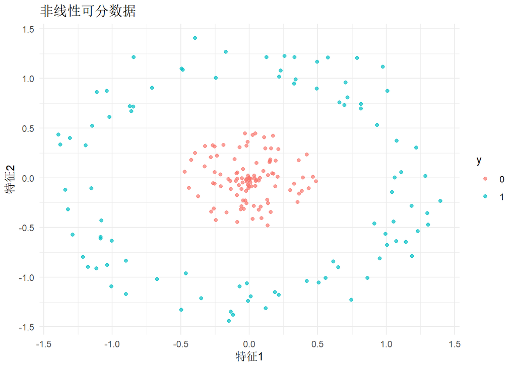

```r
# 不同核函数比较
set.seed(42)

# 创建非线性可分数据（环形数据）
n <- 200
theta <- runif(n, 0, 2 * pi)
r <- ifelse(sample(c(0, 1), n, replace = TRUE) == 0,
            runif(n, 0, 0.5), runif(n, 1, 1.5))
x1 <- r * cos(theta)
x2 <- r * sin(theta)
y <- factor(ifelse(r < 0.7, 0, 1))

nonlinear_data <- data.frame(x1 = x1, x2 = x2, y = y)

# 可视化原始数据
ggplot2::ggplot(nonlinear_data, ggplot2::aes(x = x1, y = x2, color = y)) +
  ggplot2::geom_point(alpha = 0.7) +
  ggplot2::labs(
    title = "非线性可分数据",
    x = "特征1", y = "特征2"
  ) +
  ggplot2::theme_minimal()
```

### 线性核SVM

```r
# 线性核
svm_linear <- e1071::svm(y ~ x1 + x2,
                          data = nonlinear_data,
                          kernel = "linear",
                          cost = 1)

# 预测准确率
pred_linear <- predict(svm_linear, nonlinear_data)
acc_linear <- mean(pred_linear == nonlinear_data$y)
print(paste("线性核准确率:", round(acc_linear, 3)))
```

```
## [1] "线性核准确率: 0.71"
```

### 多项式核SVM

```r
# 多项式核
svm_poly <- e1071::svm(y ~ x1 + x2,
                        data = nonlinear_data,
                        kernel = "polynomial",
                        degree = 3,
                        coef0 = 1,
                        cost = 1)

pred_poly <- predict(svm_poly, nonlinear_data)
acc_poly <- mean(pred_poly == nonlinear_data$y)
print(paste("多项式核准确率:", round(acc_poly, 3)))
```

```
## [1] "多项式核准确率: 1"
```

### RBF核SVM

```r
# RBF核（径向基核）
svm_rbf <- e1071::svm(y ~ x1 + x2,
                       data = nonlinear_data,
                       kernel = "radial",
                       gamma = 1,
                       cost = 1)

pred_rbf <- predict(svm_rbf, nonlinear_data)
acc_rbf <- mean(pred_rbf == nonlinear_data$y)
print(paste("RBF核准确率:", round(acc_rbf, 3)))
```

```
## [1] "RBF核准确率: 1"
```

### 核函数对比

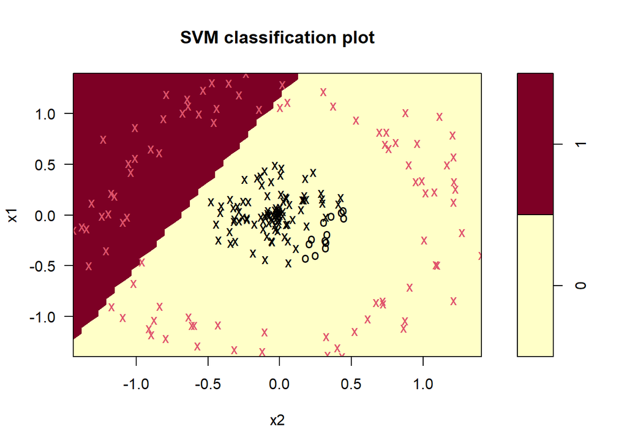

```r
# 可视化不同核函数的决策边界
plot(svm_linear, nonlinear_data, x1 ~ x2, main = "线性核")
```

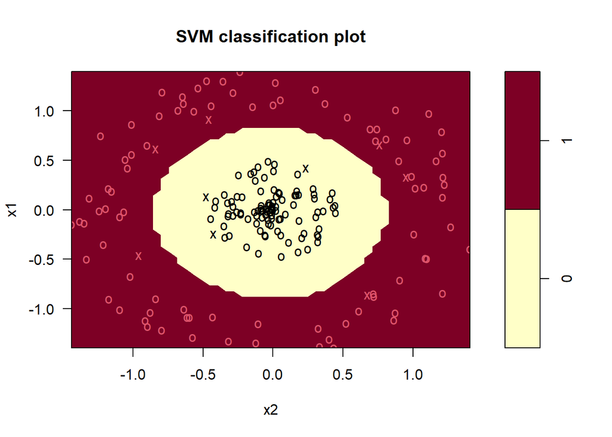

```r
plot(svm_poly, nonlinear_data, x1 ~ x2, main = "多项式核")
```

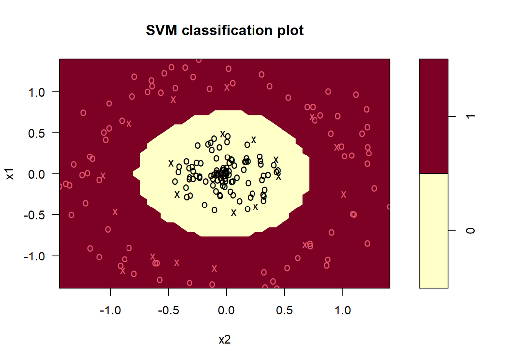

```r
plot(svm_rbf, nonlinear_data, x1 ~ x2, main = "RBF核")
```